# Assigment 2

The Winners <- c( Xhesjana Shametaj, Riccardo Dal Cero, Alice Pratesi, Federico Vicentini )

2022-06-13

```r
# PRELIMINARY OPERATIONS

# Clear the variables
rm(list = ls())


# Set the working directory to source file location with
# setwd(dirname(rstudioapi::getActiveDocumentContext()$path))


# Install packages
packages <- c("tidyverse", "rsdmx", "eurostat", "tbl2xts",
              "tidyquant", "BCDating", "pwt10", "dplyr",
              "stargazer", "car", "forecast", "tseries",
              "quantmod", "eurostat", "stargazer",
              "skedastic","Metrics","mFilter", "aTSA","lmtest","xts")
new.packages <- packages[!(packages %in% installed.packages()[, "Package"])]
if (length(new.packages)) install.packages(new.packages)
invisible(lapply(packages, library, character.only = TRUE))

# Load packages
library(quantmod)
library(eurostat)
```

## Q1: Data Generating Process

We simulate an AR(i), a MA(i) and an ARMA(i,j) study the correlogram, where we choose i and j as positive integers, while the parameters can be positive or negative.

```r
set.seed(1111)
```

We define functions: - to generate a general ARMA time series of order i,j so that it could be also an AR or an MA - to fit the ARMA function - to plot the different correlations

```r
arma=function(ar,ma){
  armats <- arima.sim(model=list(ar=ar,ma=ma), n=1000)
  armats
  return(armats)
}

armafit=function(armats,order){
  armatsfit = arima(armats, order, include.mean = FALSE)
  return(armatsfit)
}

plotcorr=function(ts,main){
  plot(ts, type="l", main=main)
  acf(ts, main=main)
  pacf(ts, main=main)
}
```

# INTERPRETATION 1

We simulate four AR(1): two with positive parameters and the other two with negative parameters

```r
#Simulate an AR(1) with a positive parameter
ar=c(0.3)
ma=c(0)
order=c(1,0,0)
arts1=arma(ar,ma)
artsfit1 = armafit(arts1, order)
stargazer(artsfit1, type="text")
```

```
##
## =============================================
##                       Dependent variable:
##                   ---------------------------
##                             armats
## ---------------------------------------------
## ar1                        0.342***
##                             (0.030)
##
## ---------------------------------------------
## Observations                 1,000
## Log Likelihood            -1,405.245
## sigma2                       0.973
## Akaike Inf. Crit.          2,814.490
## =============================================
## Note:             *p<0.1; **p<0.05; ***p<0.01
```

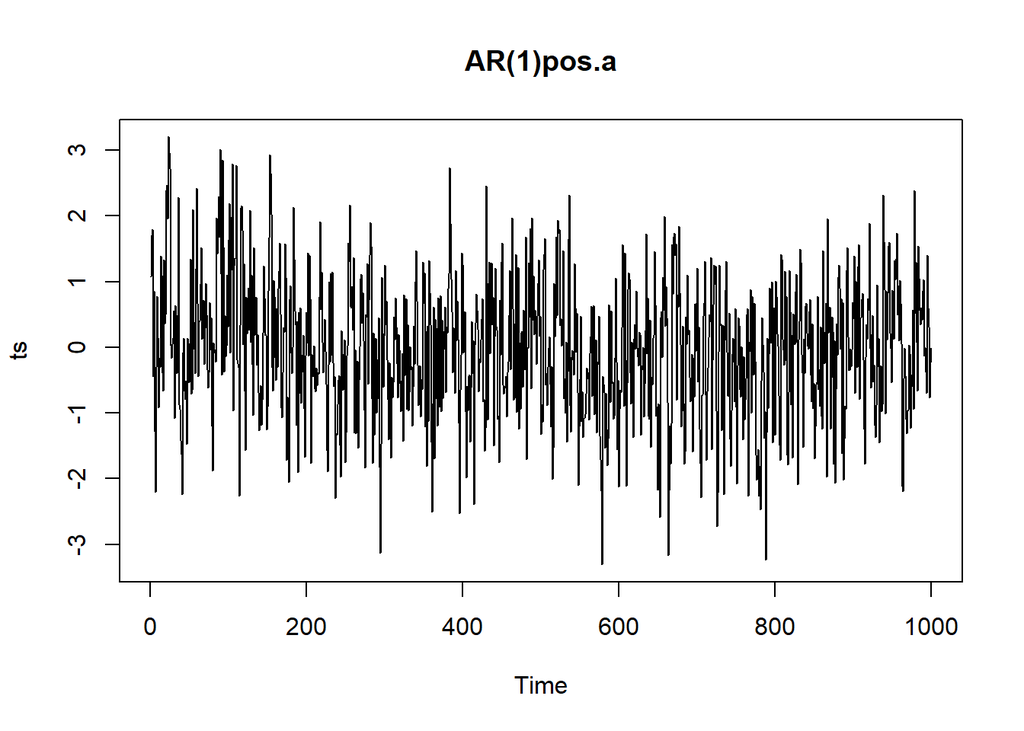

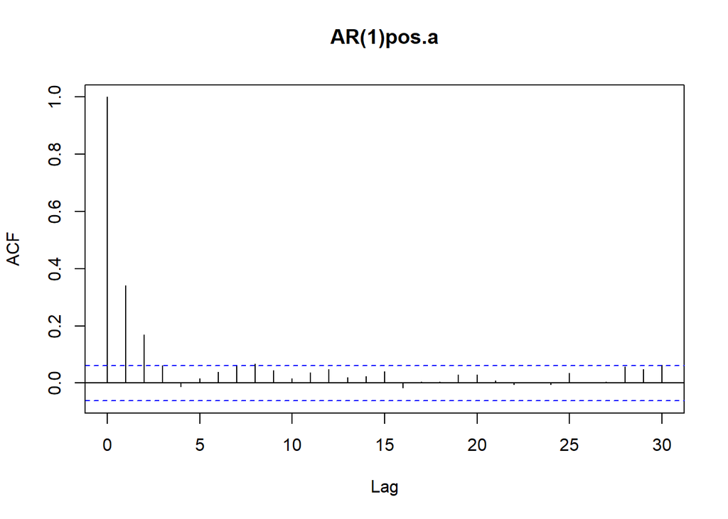

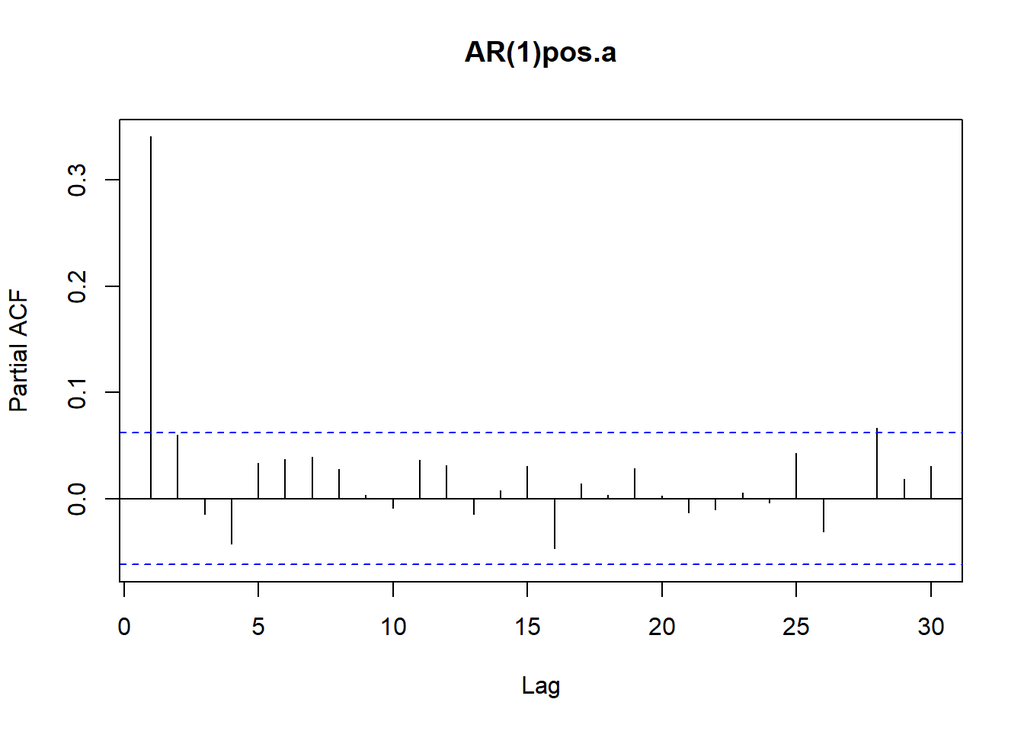

```r
plotcorr(arts1,main="AR(1)pos.a")
```

```r
#Simulate an AR(1) with a positive parameter
ar=c(0.5)
ma=c(0)
order=c(1,0,0)
arts2=arma(ar,ma)
artsfit2 = armafit(arts2, order)
stargazer(artsfit2, type="text")
```

```
##
## =============================================
##                       Dependent variable:
##                   ---------------------------
##                             armats
## ---------------------------------------------
## ar1                        0.485***
##                             (0.028)
##
## ---------------------------------------------
## Observations                 1,000
## Log Likelihood            -1,399.882
## sigma2                       0.962
## Akaike Inf. Crit.          2,803.764
## =============================================
## Note:             *p<0.1; **p<0.05; ***p<0.01
```

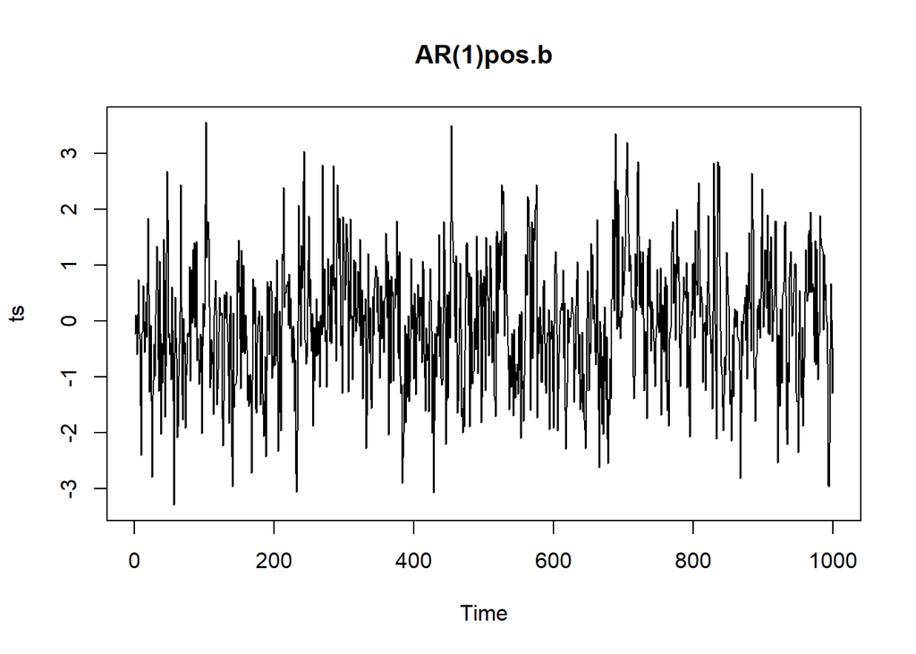

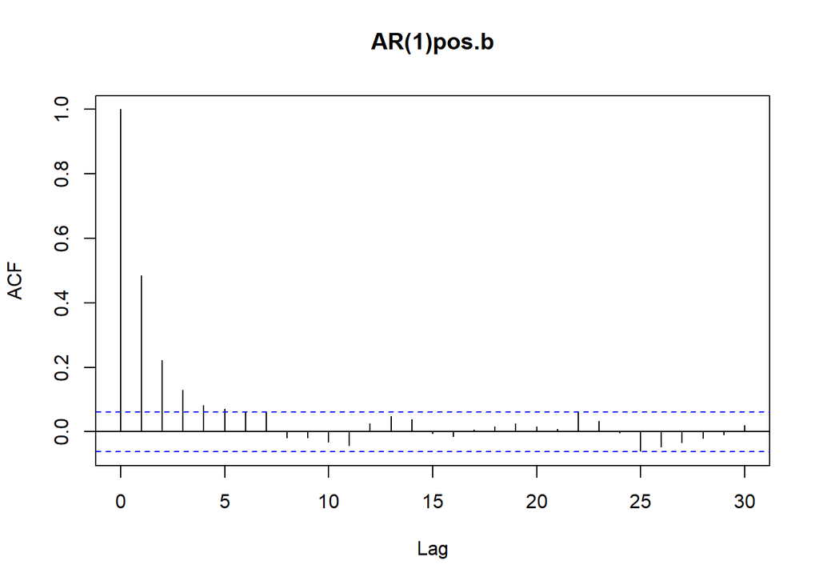

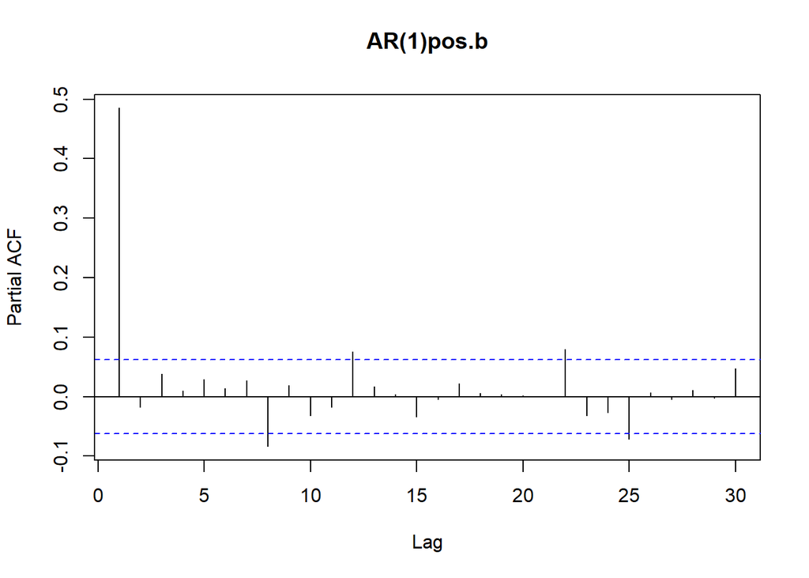

```r
plotcorr(arts2,main="AR(1)pos.b")
```

```r
#Simulate an AR(1) with a negative parameter
ar=c(-0.3)
ma=c(0)
order=c(1,0,0)
arts3=arma(ar,ma)
artsfit3 = armafit(arts3, order)
stargazer(artsfit3, type="text")
```

```
##
## =============================================
##                       Dependent variable:
##                   ---------------------------
##                             armats
## ---------------------------------------------
## ar1                        -0.291***
##                             (0.030)
##
## ---------------------------------------------
## Observations                 1,000
## Log Likelihood            -1,428.626
## sigma2                       1.019
## Akaike Inf. Crit.          2,861.251
## =============================================
## Note:             *p<0.1; **p<0.05; ***p<0.01
```

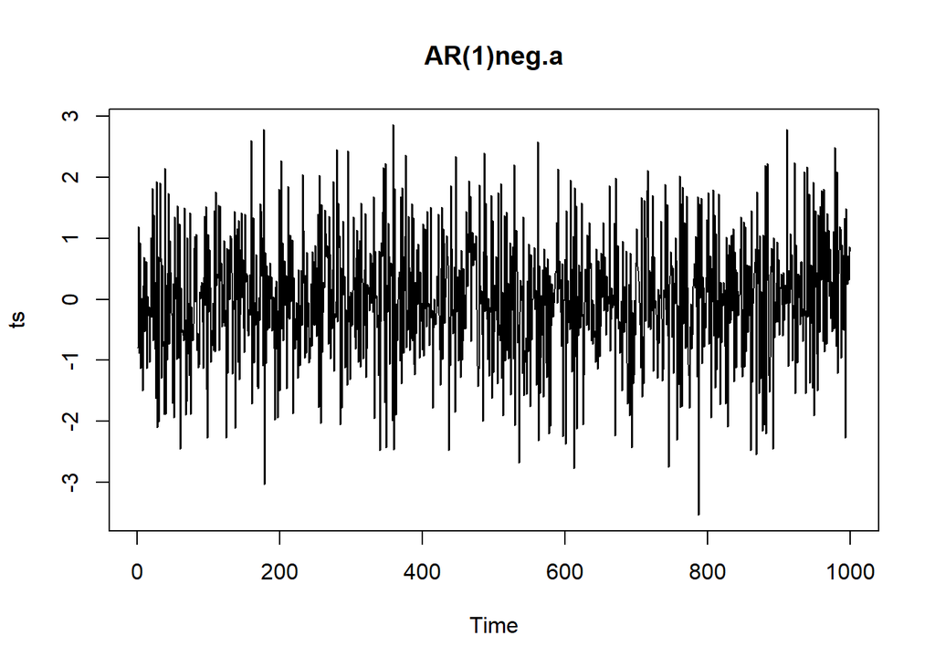

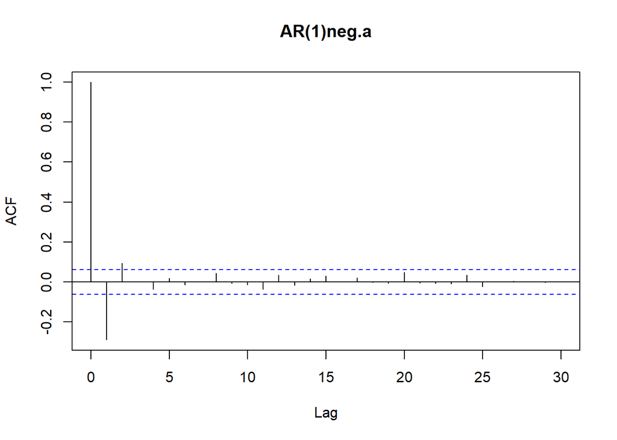

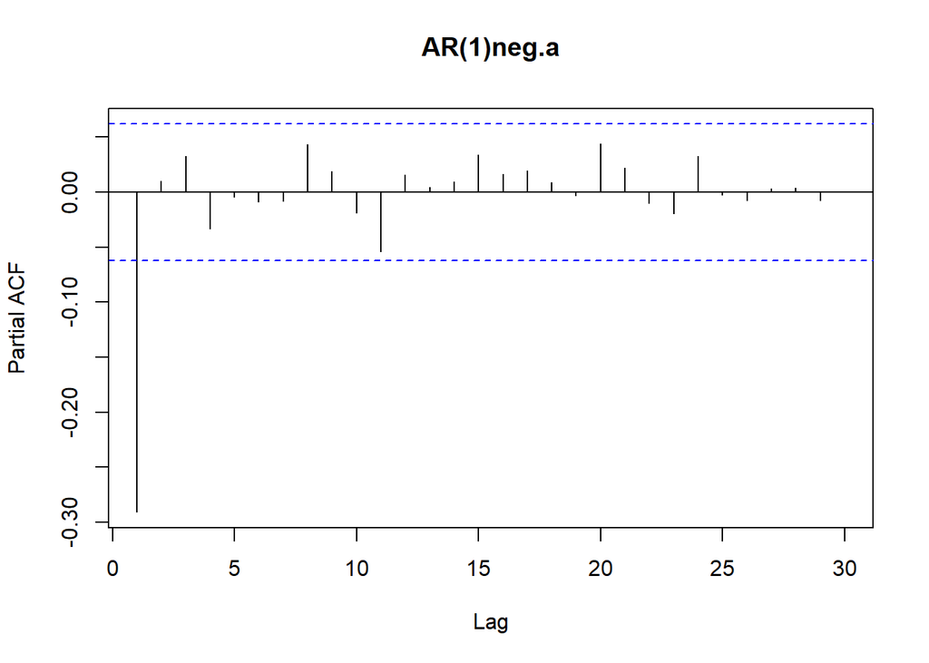

```r
plotcorr(arts3,main="AR(1)neg.a")
```

```r
#Simulate an AR(1) with a negative parameter
ar=c(-0.5)
ma=c(0)
order=c(1,0,0)
arts4=arma(ar,ma)
artsfit4 = armafit(arts4, order)
stargazer(artsfit4, type="text")
```

```
##
## =============================================
##                       Dependent variable:
##                   ---------------------------
##                             armats
## ---------------------------------------------
## ar1                        -0.501***
##                             (0.027)
##
## ---------------------------------------------
## Observations                 1,000
## Log Likelihood            -1,440.495
## sigma2                       1.044
## Akaike Inf. Crit.          2,884.990
## =============================================
## Note:             *p<0.1; **p<0.05; ***p<0.01
```

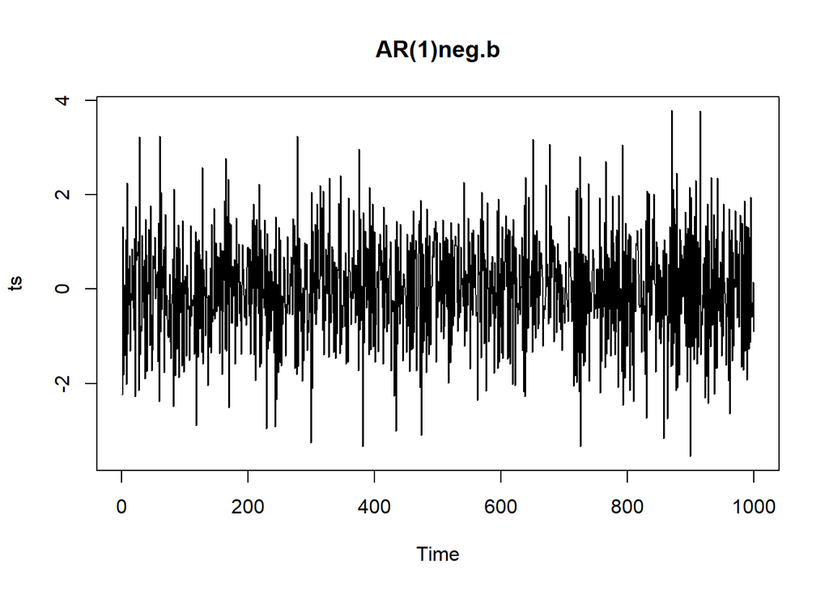

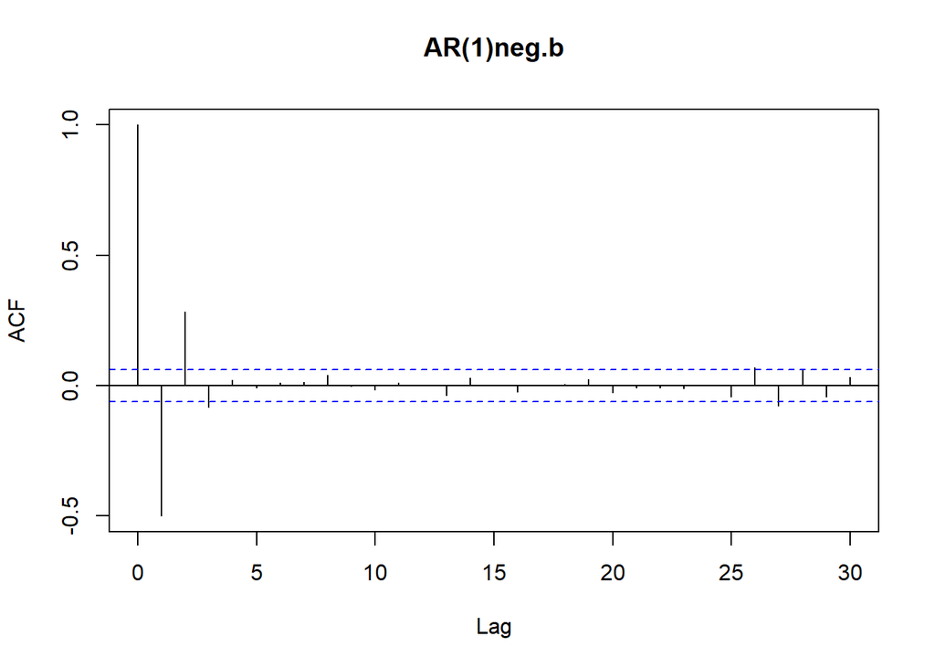

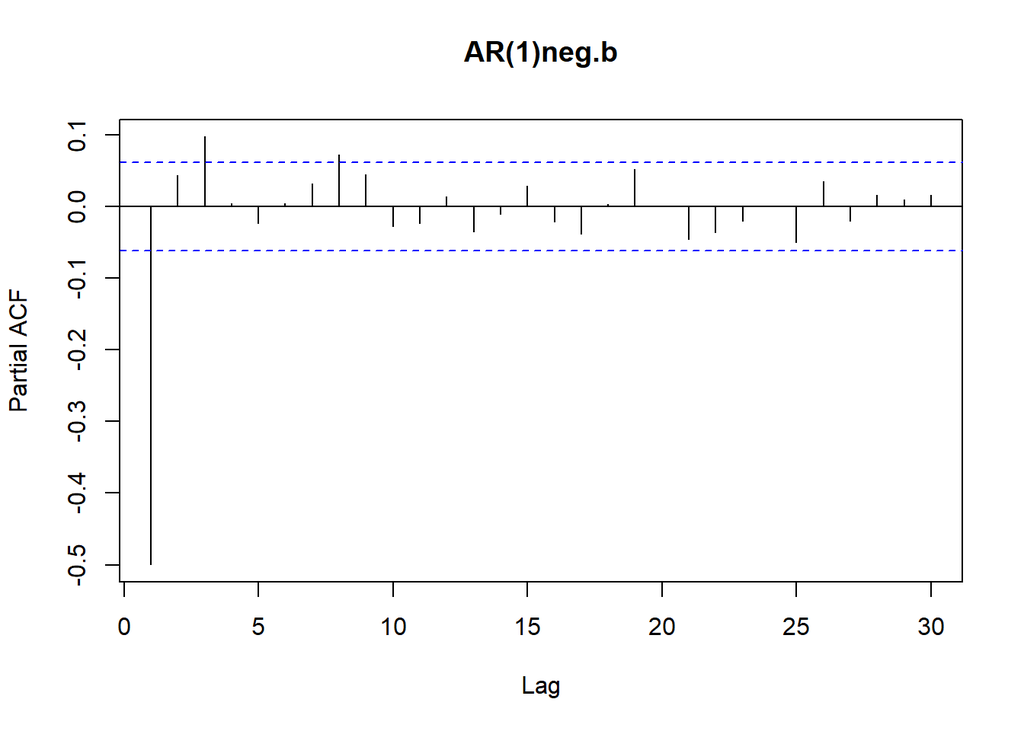

```r
plotcorr(arts4,main="AR(1)neg.b")
```

We simulate four MA(1): two with positive parameters and the other two with negative parameters

```r
#Simulate an MA(1) with a positive parameter
ar=c(0)
ma=c(0.2)
order=c(0,0,1)
mats1=arma(ar,ma)
matsfit1 = armafit(mats1, order)
stargazer(matsfit1, type="text")
```

```
##
## =============================================
##                       Dependent variable:
##                   ---------------------------
##                             armats
## ---------------------------------------------
## ma1                        0.206***
##                             (0.032)
##
## ---------------------------------------------
## Observations                 1,000
## Log Likelihood            -1,410.510
## sigma2                       0.983
## Akaike Inf. Crit.          2,825.019
## =============================================
## Note:             *p<0.1; **p<0.05; ***p<0.01
```

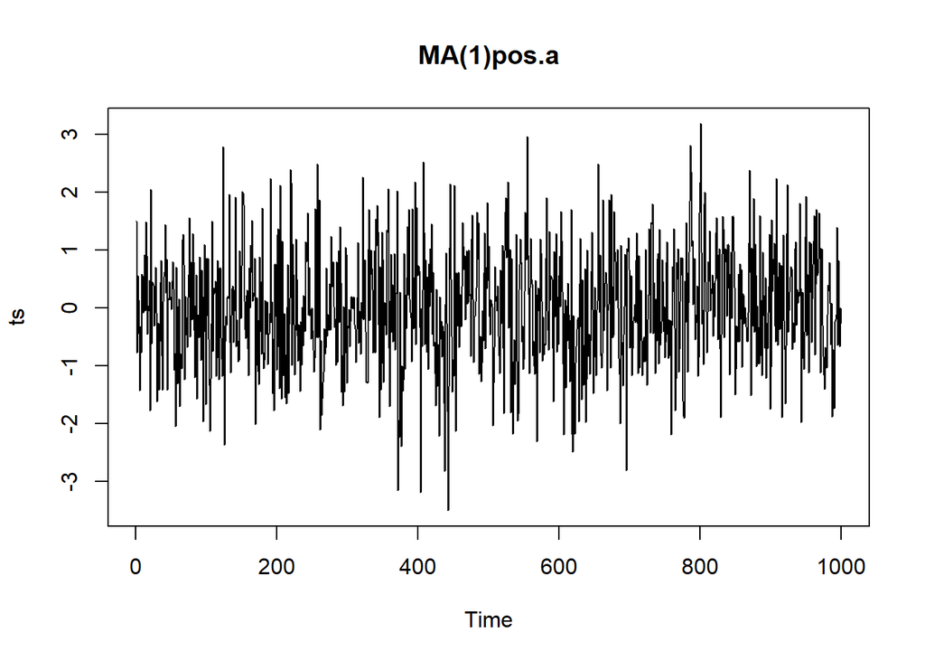

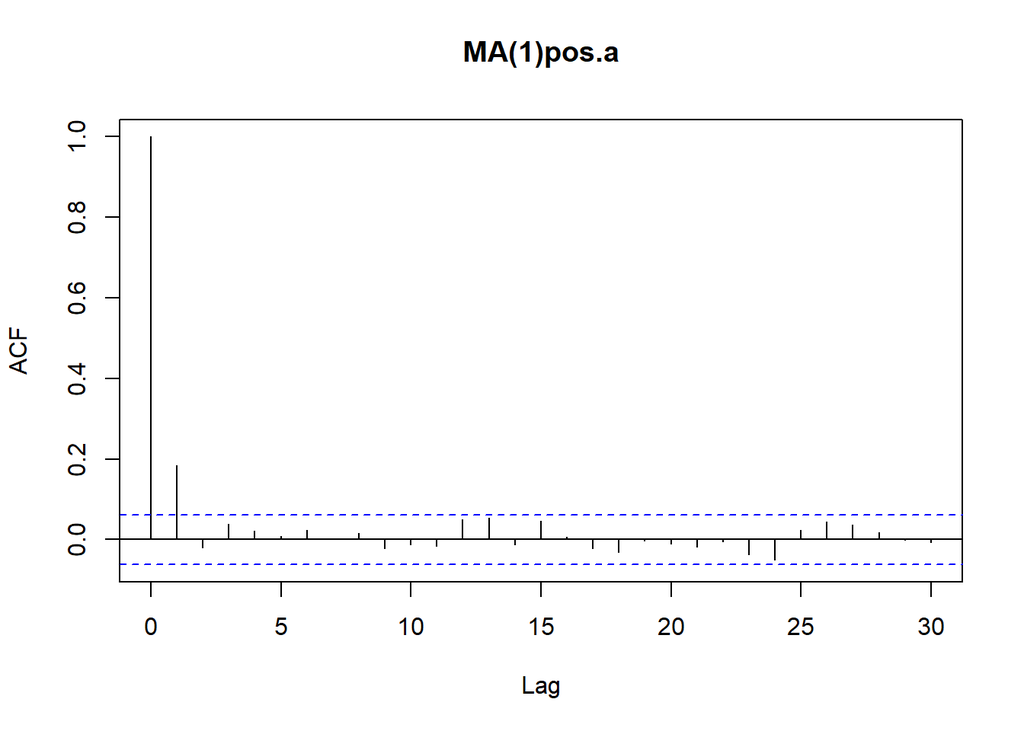

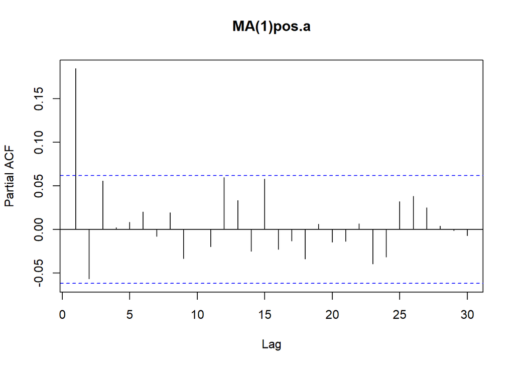

```r
plotcorr(mats1,main="MA(1)pos.a")
```

```r
#Simulate an MA(1) with a positive parameter
ar=c(0)
ma=c(0.3)
order=c(0,0,1)
mats2=arma(ar,ma)
matsfit2 = armafit(mats2, order)
stargazer(matsfit2, type="text")
```

```
##
## =============================================
##                       Dependent variable:
##                   ---------------------------
##                             armats
## ---------------------------------------------
## ma1                        0.259***
##                             (0.030)
##
## ---------------------------------------------
## Observations                 1,000
## Log Likelihood            -1,446.512
## sigma2                       1.057
## Akaike Inf. Crit.          2,897.024
## =============================================
## Note:             *p<0.1; **p<0.05; ***p<0.01
```

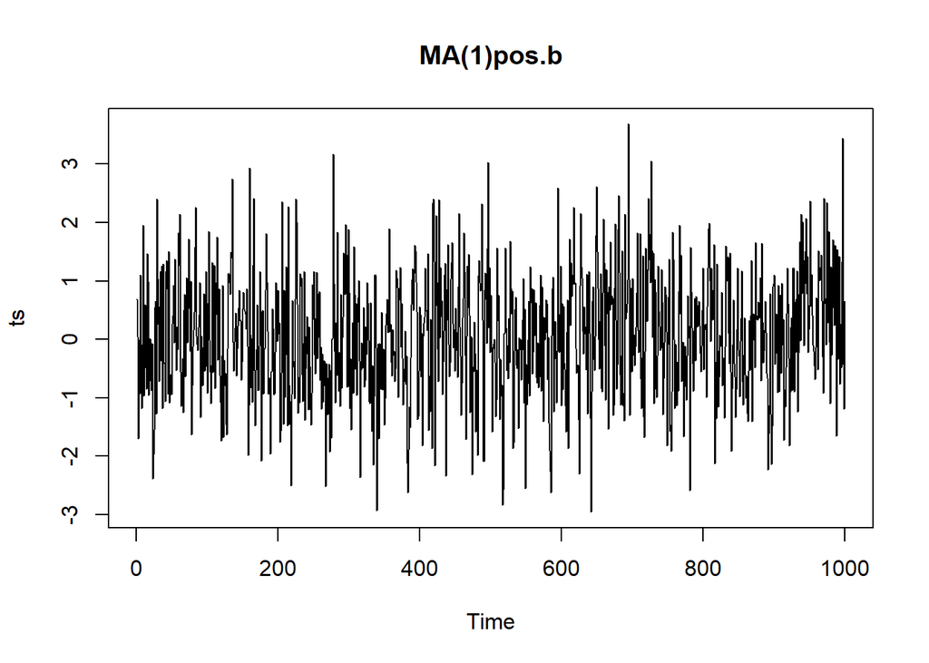

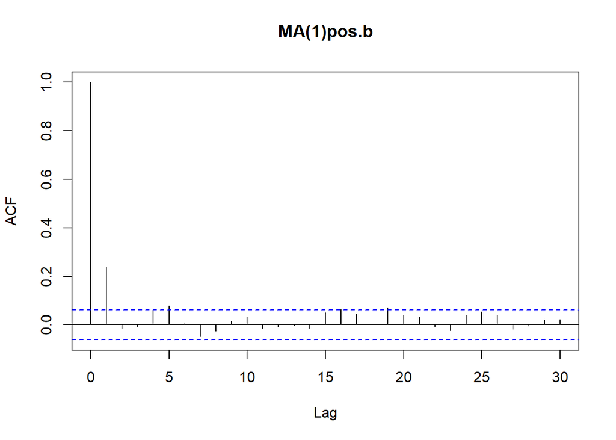

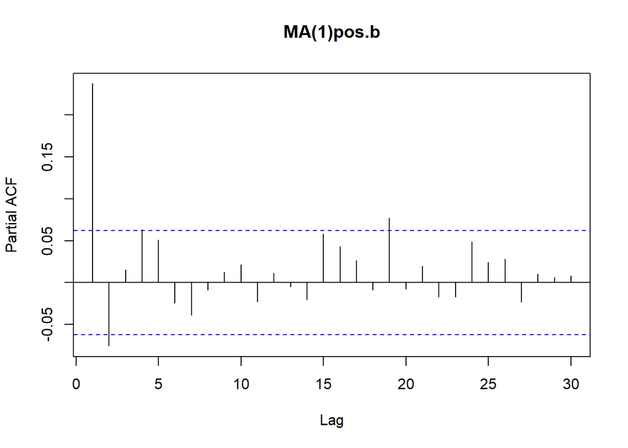

```r
plotcorr(mats2,main="MA(1)pos.b")
```

```r
#Simulate an MA(1) with a negative parameter
ar=c(0)
ma=c(-0.2)
order=c(0,0,1)
mats3=arma(ar,ma)
matsfit3 = armafit(mats3, order)
stargazer(matsfit3, type="text")
```

```
##
## =============================================
##                       Dependent variable:
##                   ---------------------------
##                             armats
## ---------------------------------------------
## ma1                        -0.227***
##                             (0.030)
##
## ---------------------------------------------
## Observations                 1,000
## Log Likelihood            -1,394.039
## sigma2                       0.951
## Akaike Inf. Crit.          2,792.079
## =============================================
## Note:             *p<0.1; **p<0.05; ***p<0.01
```

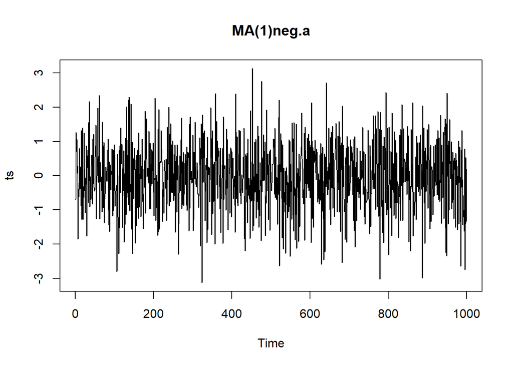

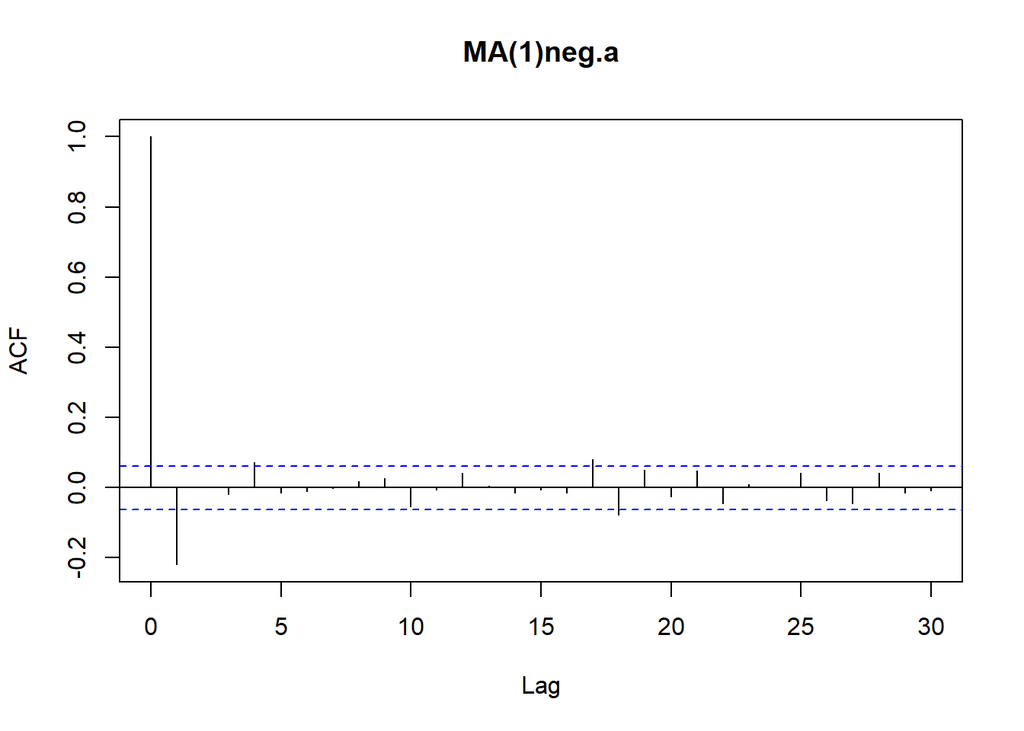

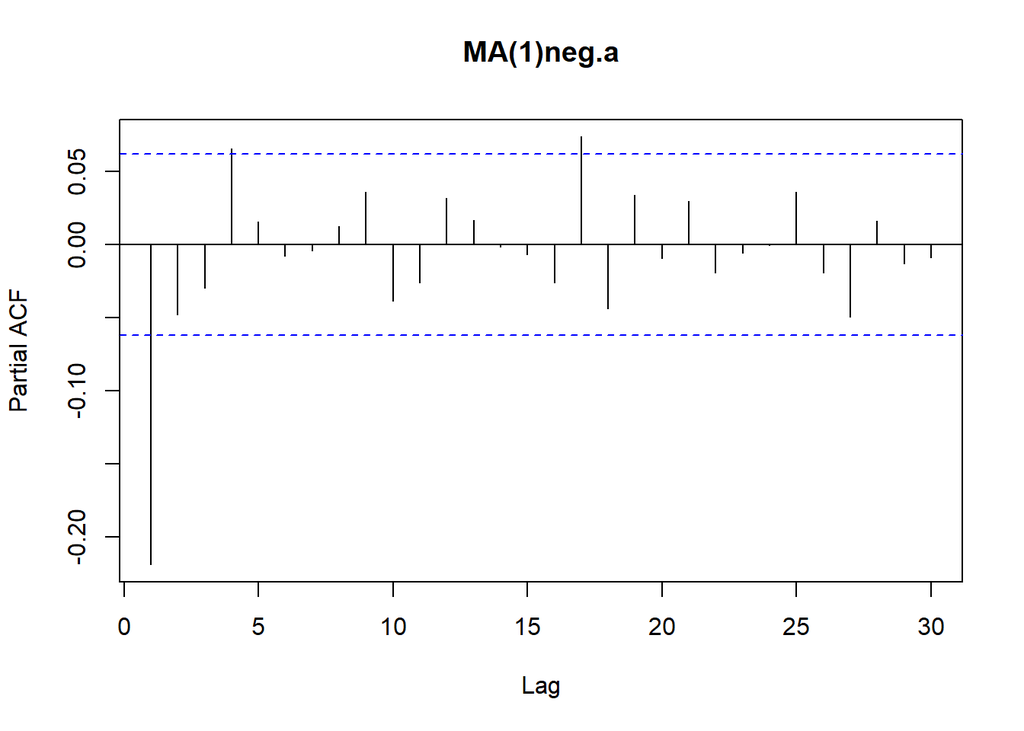

```r
plotcorr(mats3,main="MA(1)neg.a")
```

```r
#Simulate an MA(1) with a negative parameter
ar=c(0)
ma=c(-0.3)
order=c(0,0,1)
mats4=arma(ar,ma)
matsfit4 = armafit(mats4, order)
stargazer(matsfit4, type="text")
```

```
##
## =============================================
##                       Dependent variable:
##                   ---------------------------
##                             armats
## ---------------------------------------------
## ma1                        -0.361***
##                             (0.029)
##
## ---------------------------------------------
## Observations                 1,000
## Log Likelihood            -1,452.535
## sigma2                       1.069
## Akaike Inf. Crit.          2,909.069
## =============================================
## Note:             *p<0.1; **p<0.05; ***p<0.01
```

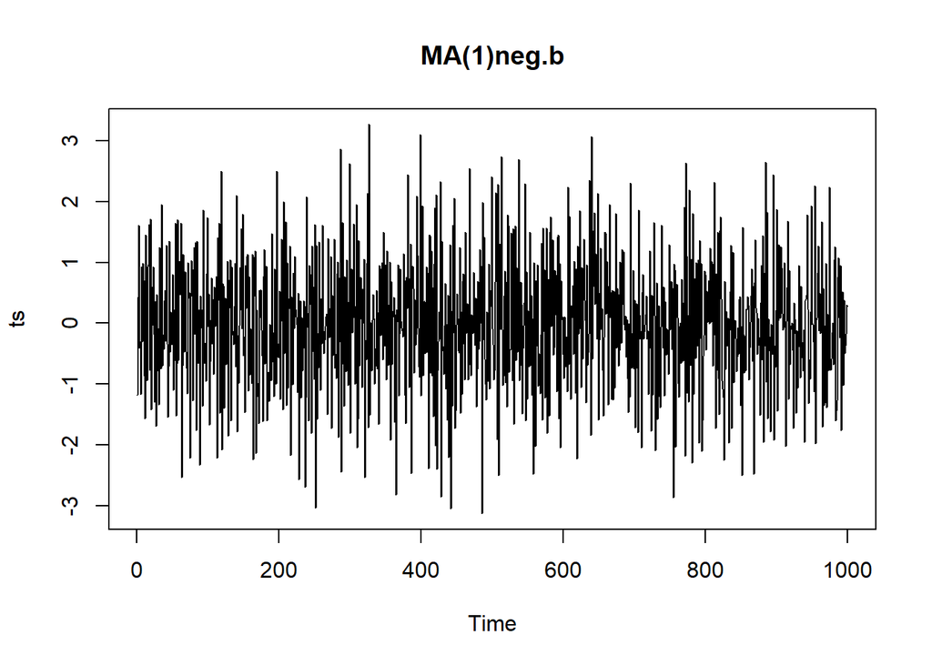

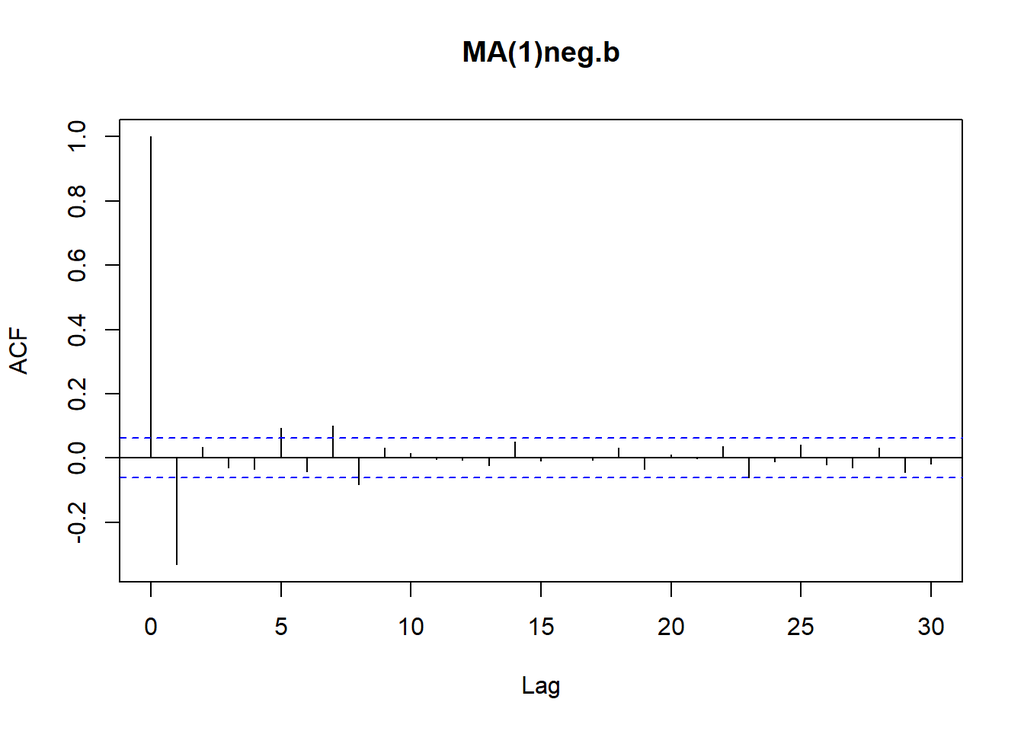

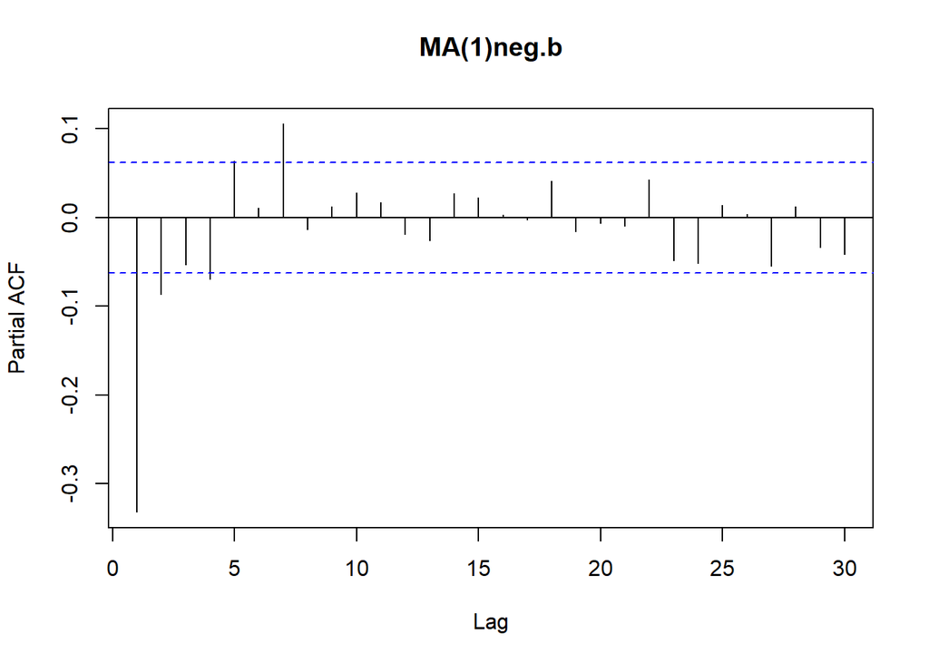

```r
plotcorr(mats4,main="MA(1)neg.b")
```

As we saw before, all graphs are coherent with the parameters we set.

After simulating AR(1) and MA(1), we simulate one ARMA(1,1) and one ARMA(2,2).

```r
# Simulate an ARMA(1,1) with certain parameters
ar=c(0.4)
ma=c(0.5)
order=c(1,0,1)
armats1=arma(ar,ma)
armatsfit1 = armafit(armats1, order)
stargazer(armatsfit1, type="text")
```

```
##
## =============================================
##                       Dependent variable:
##                   ---------------------------
##                             armats
## ---------------------------------------------
## ar1                        0.473***
##                             (0.037)
##
## ma1                        0.451***
##                             (0.038)
##
## ---------------------------------------------
## Observations                 1,000
## Log Likelihood            -1,451.712
## sigma2                       1.067
## Akaike Inf. Crit.          2,909.424
## =============================================
## Note:             *p<0.1; **p<0.05; ***p<0.01
```

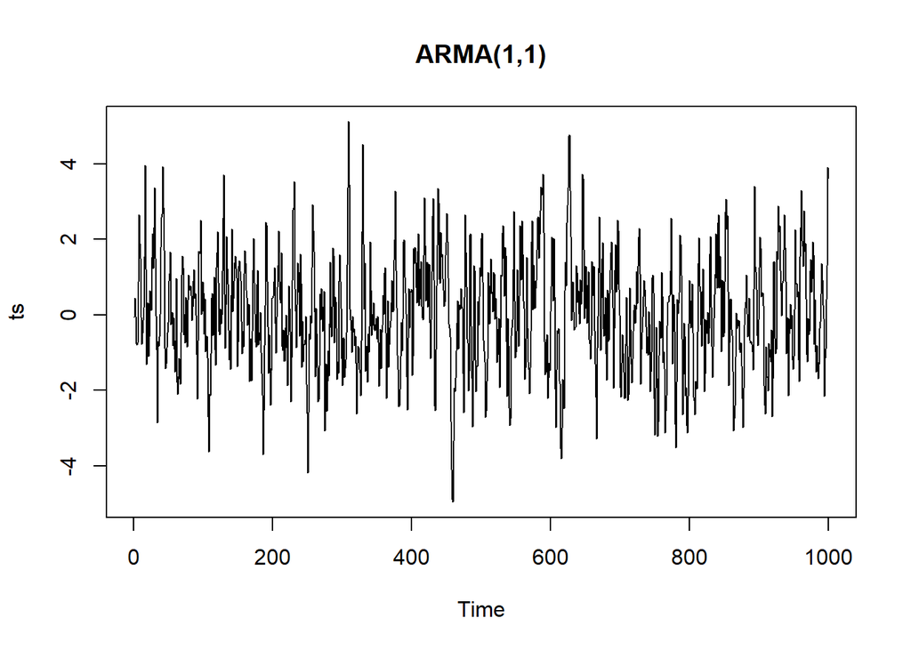

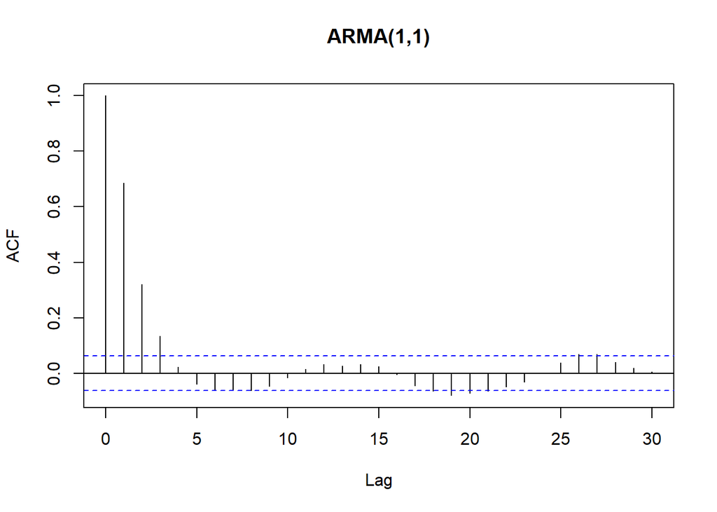

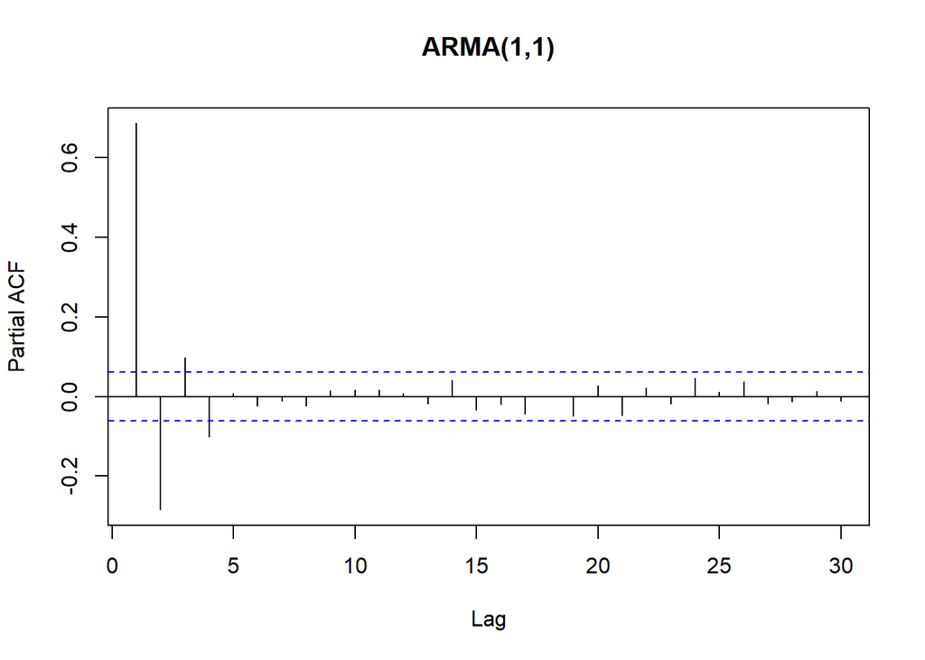

```r
plotcorr(armats1,main="ARMA(1,1)")
```

```r
# Simulate an ARMA(2,2) with certain parameters
ar=c(0.3,-0.5)
ma=c(-0.2, 0.2)
order=c(2,0,2)
armats2=arma(ar,ma)
armatsfit2 = armafit(armats2, order)
stargazer(armatsfit2, type="text")
```

```
##
## =============================================
##                       Dependent variable:
##                   ---------------------------
##                             armats
## ---------------------------------------------
## ar1                        0.303***
##                             (0.090)
##
## ar2                        -0.504***
##                             (0.079)
##
## ma1                        -0.239**
##                             (0.102)
##
## ma2                        0.227***
##                             (0.088)
##
## ---------------------------------------------
## Observations                 1,000
## Log Likelihood            -1,421.158
## sigma2                       1.004
## Akaike Inf. Crit.          2,852.317
## =============================================
## Note:             *p<0.1; **p<0.05; ***p<0.01
```

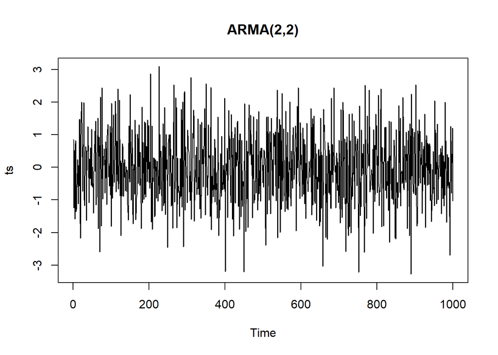

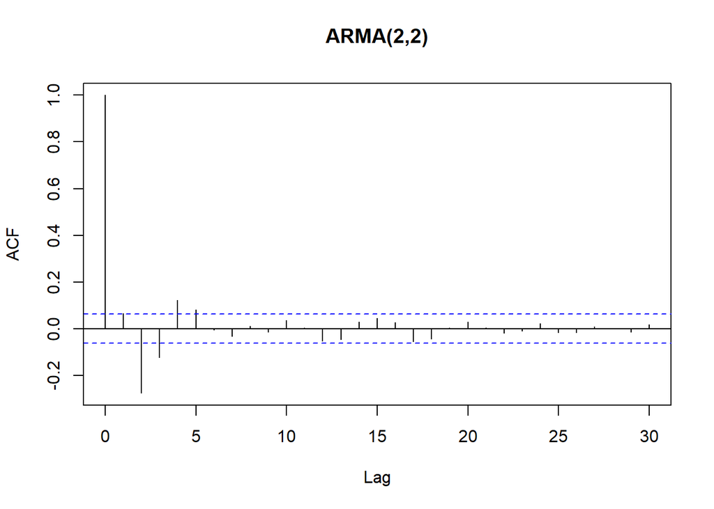

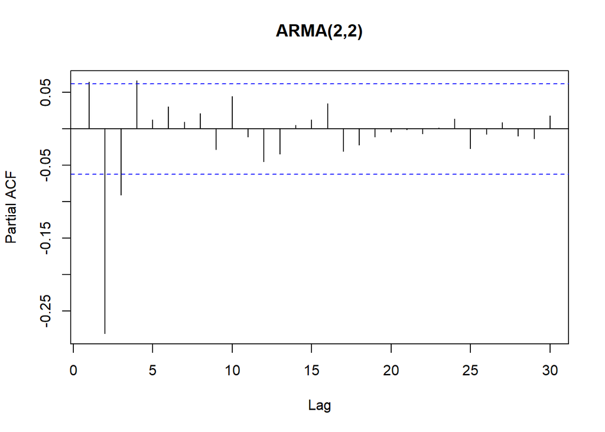

```r
plotcorr(armats2,main="ARMA(2,2)")
```

Here the same conclusion applies: coefficients and graphs are coherent with what we set as parameters when simulating the ARMA.

# INTERPRETATION 2

We simulate two AR(): 1. AR(4) with two positive parameters and two negative parameters 2. AR(6) with three positive parameters and three negative parameters

```r
#Simulate an AR(4) with certain parameters
ar=c(0.3,0.25,-0.22,-0.15)
ma=c(0)
order=c(4,0,0)
arts1=arma(ar,ma)
artsfit1 = armafit(arts1, order)
stargazer(artsfit1, type="text")
```

```
##
## =============================================
##                       Dependent variable:
##                   ---------------------------
##                             armats
## ---------------------------------------------
## ar1                        0.311***
##                             (0.031)
##
## ar2                        0.268***
##                             (0.032)
##
## ar3                        -0.225***
##                             (0.032)
##
## ar4                        -0.130***
##                             (0.031)
##
## ---------------------------------------------
## Observations                 1,000
## Log Likelihood            -1,409.924
## sigma2                       0.982
## Akaike Inf. Crit.          2,829.849
## =============================================
## Note:             *p<0.1; **p<0.05; ***p<0.01
```

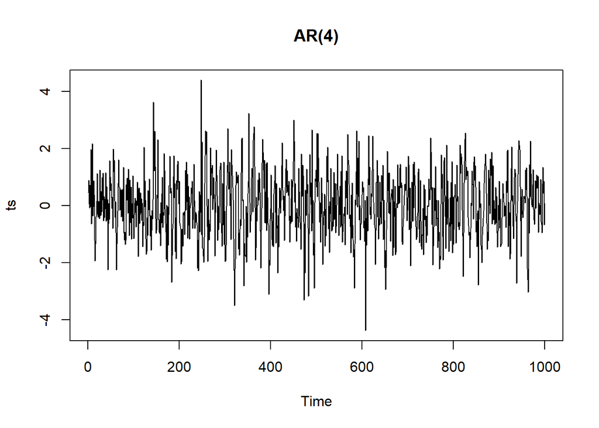

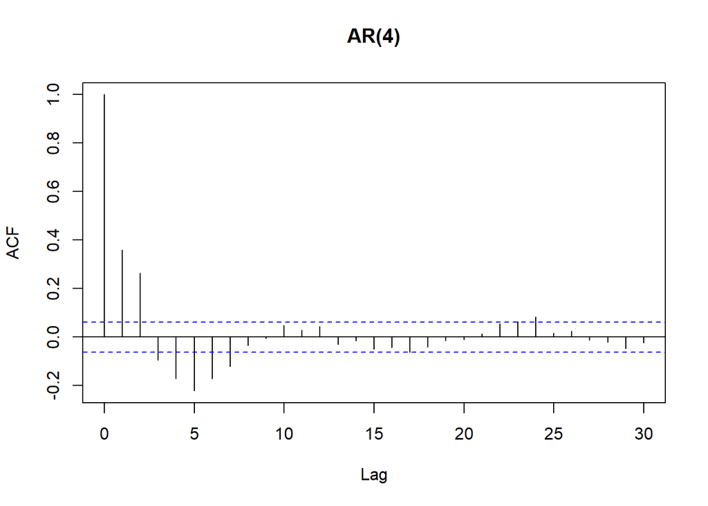

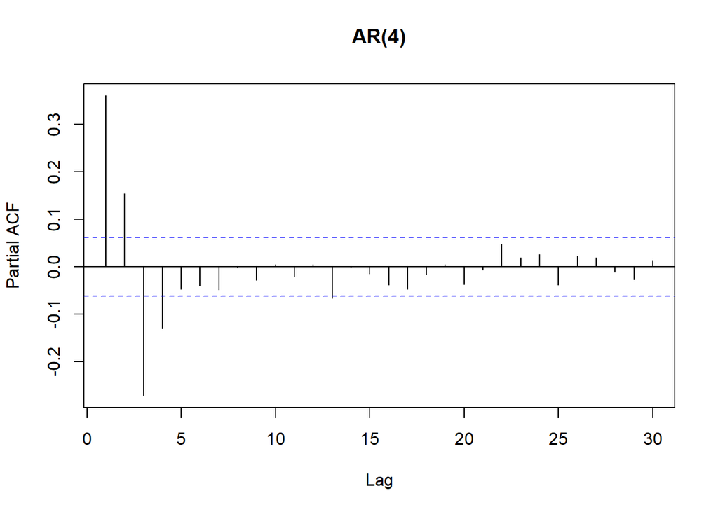

```r
plotcorr(arts1,main="AR(4)")
```

```r
# Simulate an AR(6) with certain parameters
ar=c(0.35,0.33,0.3,-0.18, -0.15, -0.1)
ma=c(0)
order=c(6,0,0)
arts2=arma(ar,ma)
artsfit2 = armafit(arts2, order)
stargazer(artsfit2, type="text")
```

```
##
## =============================================
##                       Dependent variable:
##                   ---------------------------
##                             armats
## ---------------------------------------------
## ar1                        0.362***
##                             (0.031)
##
## ar2                        0.343***
##                             (0.033)
##
## ar3                        0.294***
##                             (0.034)
##
## ar4                        -0.156***
##                             (0.034)
##
## ar5                        -0.200***
##                             (0.033)
##
## ar6                        -0.119***
##                             (0.032)
##
## ---------------------------------------------
## Observations                 1,000
## Log Likelihood            -1,402.321
## sigma2                       0.966
## Akaike Inf. Crit.          2,818.641
## =============================================
## Note:             *p<0.1; **p<0.05; ***p<0.01
```

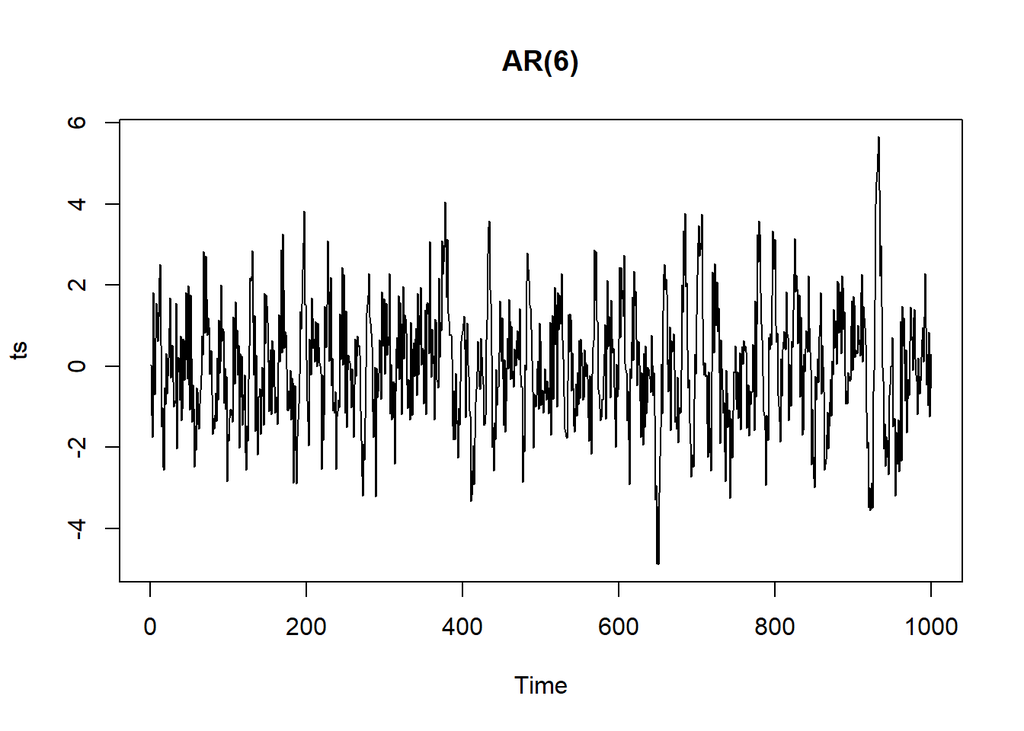

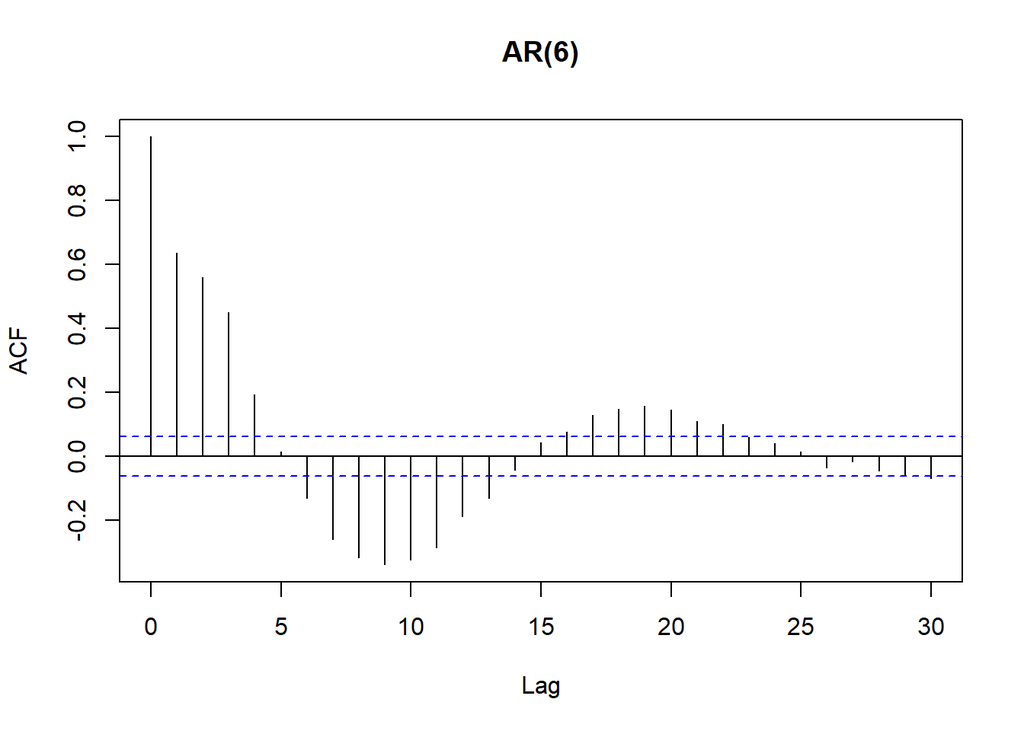

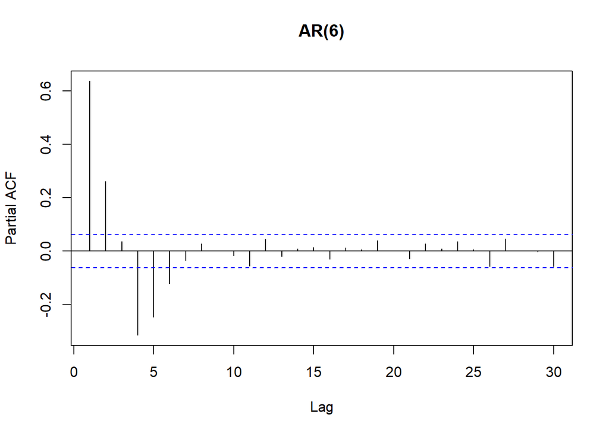

```r
plotcorr(arts2,main="AR(6)")
```

Same story as before: coefficients are coherent with what we expected, even if the presence of multiple lags tends to weaken their correspondence with the parameters we set.

We simulate two MA(): 1. MA(4) with two positive parameters and two negative parameters 2. MA(6) with three positive parameters and three negative parameters

```r
# Simulate an MA(4) with certain parameters
ar=c(0)
ma=c(0.2,0.2,-0.2,-0.2)
order=c(0,0,4)
mats1=arma(ar,ma)
matsfit1 = armafit(mats1, order)
stargazer(matsfit1, type="text")
```

```
##
## =============================================
##                       Dependent variable:
##                   ---------------------------
##                             armats
## ---------------------------------------------
## ma1                        0.190***
##                             (0.031)
##
## ma2                        0.291***
##                             (0.031)
##
## ma3                        -0.228***
##                             (0.031)
##
## ma4                        -0.215***
##                             (0.031)
##
## ---------------------------------------------
## Observations                 1,000
## Log Likelihood            -1,423.809
## sigma2                       1.009
## Akaike Inf. Crit.          2,857.619
## =============================================
## Note:             *p<0.1; **p<0.05; ***p<0.01
```

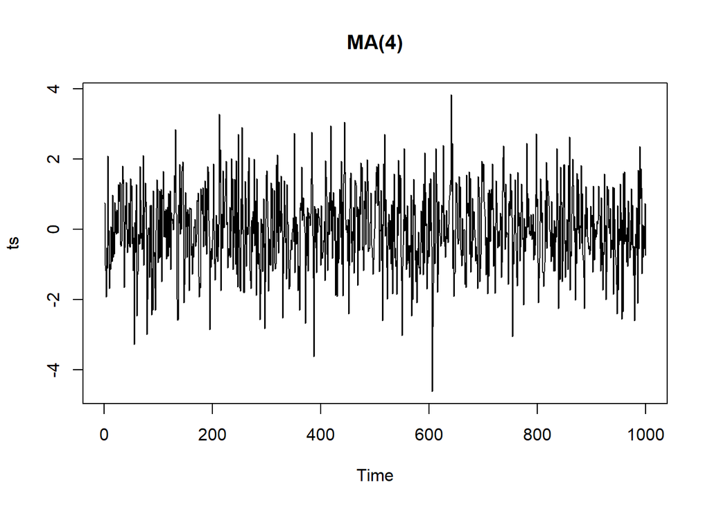

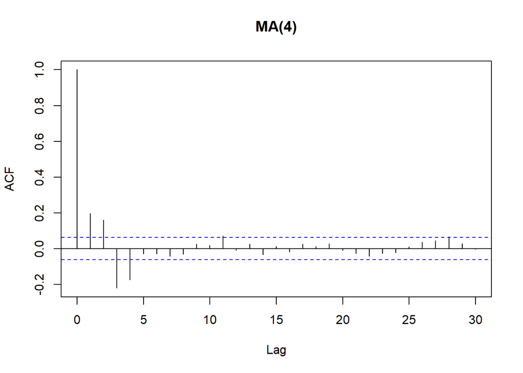

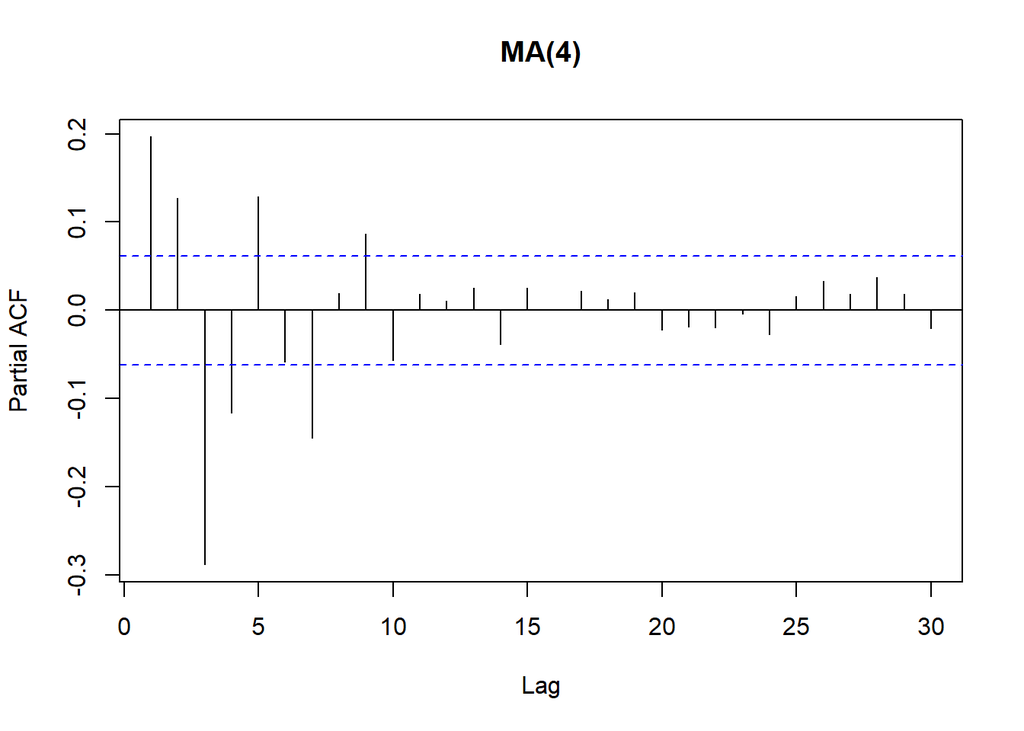

```r
plotcorr(mats1,main="MA(4)")
```

```r
# Simulate an MA(6) with certain parameters
ar=c(0)
ma=c(0.2,0.2,0.2,-0.2,-0.2,-0.2)
order=c(0,0,6)
mats2=arma(ar,ma)
matsfit2 = armafit(mats2, order)
stargazer(matsfit2, type="text")
```

```
##
## =============================================
##                       Dependent variable:
##                   ---------------------------
##                             armats
## ---------------------------------------------
## ma1                        0.196***
##                             (0.031)
##
## ma2                        0.213***
##                             (0.031)
##
## ma3                        0.234***
##                             (0.031)
##
## ma4                        -0.123***
##                             (0.031)
##
## ma5                        -0.175***
##                             (0.032)
##
## ma6                        -0.176***
##                             (0.030)
##
## ---------------------------------------------
## Observations                 1,000
## Log Likelihood            -1,451.500
## sigma2                       1.066
## Akaike Inf. Crit.          2,916.999
## =============================================
## Note:             *p<0.1; **p<0.05; ***p<0.01
```

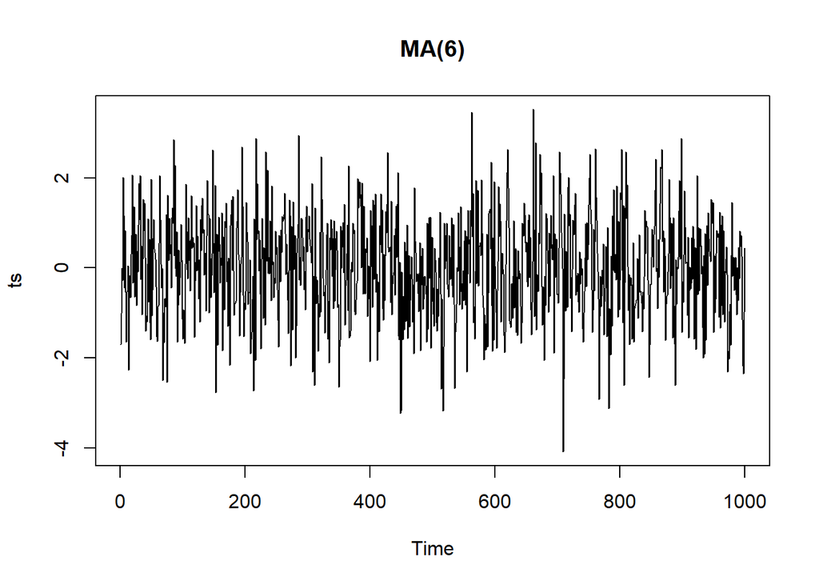

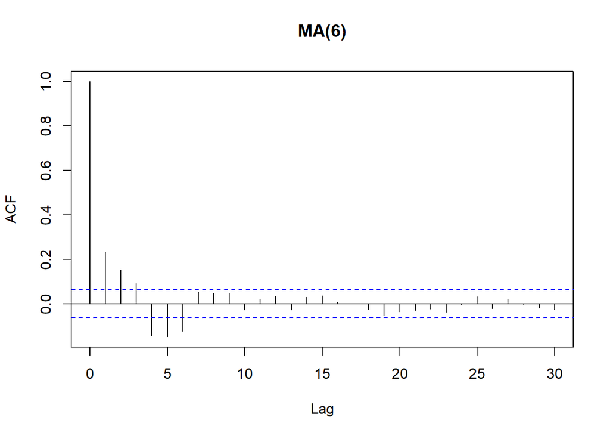

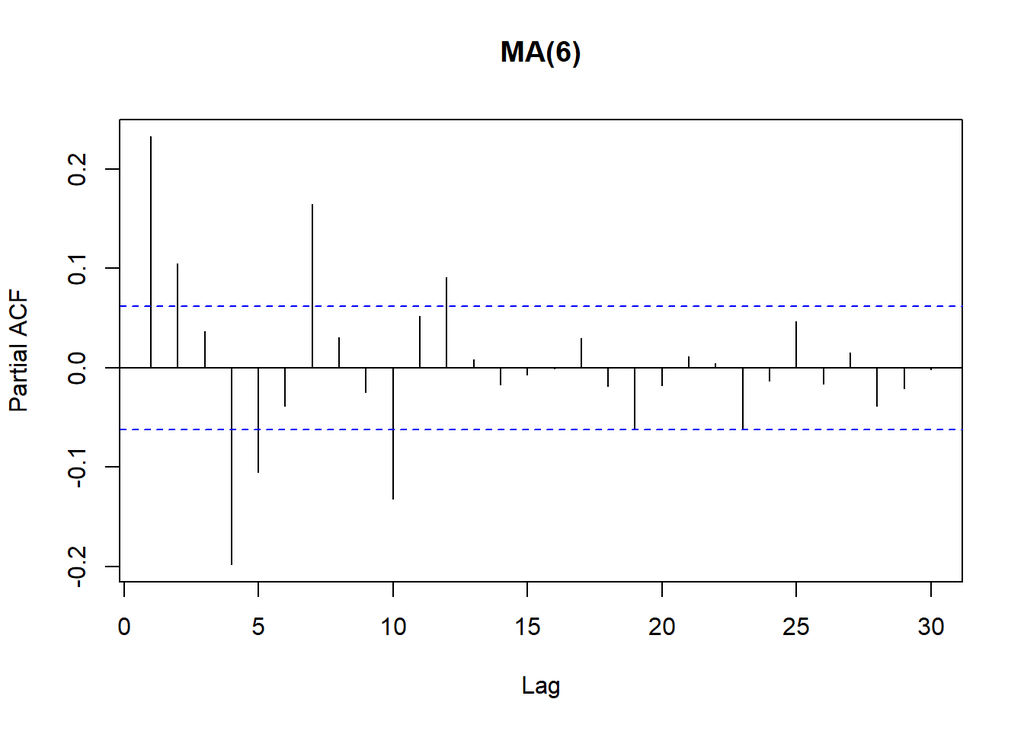

```r
plotcorr(mats2,main="MA(6)")
```

Here it’s the same coefficients are coherent with what we expected, even if the presence of multiple lags tends to weaken their correspondence with the parameters we set.

After simulating AR() and MA(), we simulate one ARMA(3,1) and one ARMA(1,3).

```r
# Simulate an ARMA(3,1) with certain parameters
ar=c(0.2,0.2,-0.2)
ma=c(-0.2)
order=c(3,0,1)
armats1=arma(ar,ma)
armatsfit1 = armafit(armats1, order)
stargazer(armatsfit1, type="text")
```

```
##
## =============================================
##                       Dependent variable:
##                   ---------------------------
##                             armats
## ---------------------------------------------
## ar1                          0.054
##                             (0.154)
##
## ar2                        0.216***
##                             (0.032)
##
## ar3                        -0.190***
##                             (0.044)
##
## ma1                         -0.093
##                             (0.156)
##
## ---------------------------------------------
## Observations                 1,000
## Log Likelihood            -1,470.919
## sigma2                       1.109
## Akaike Inf. Crit.          2,951.839
## =============================================
## Note:             *p<0.1; **p<0.05; ***p<0.01
```

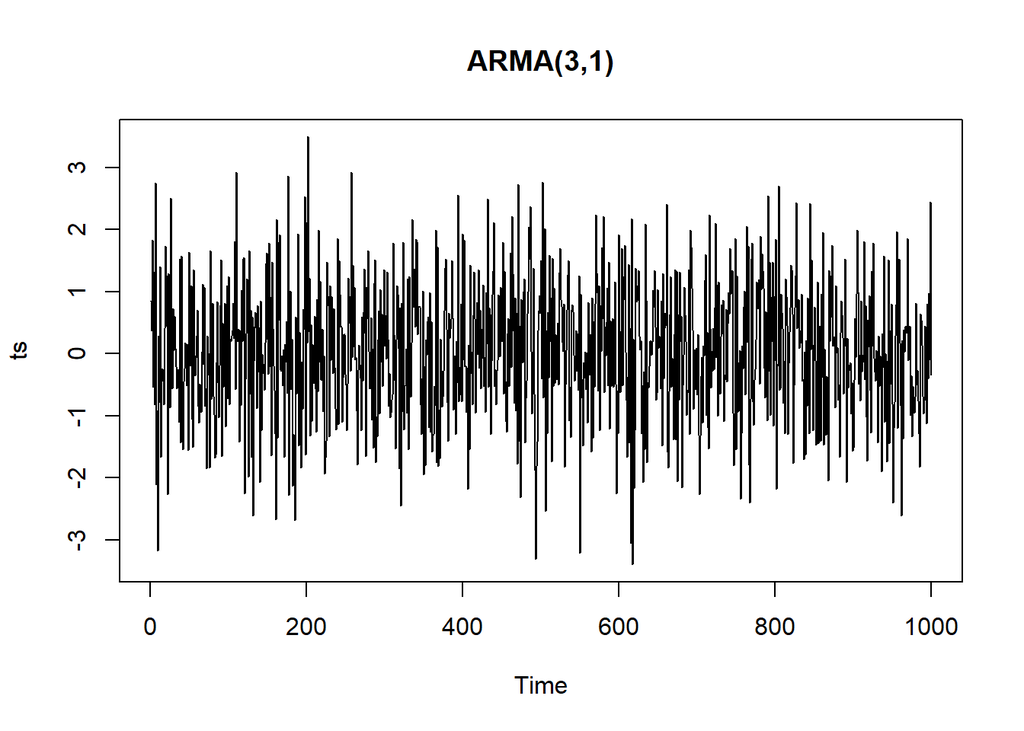

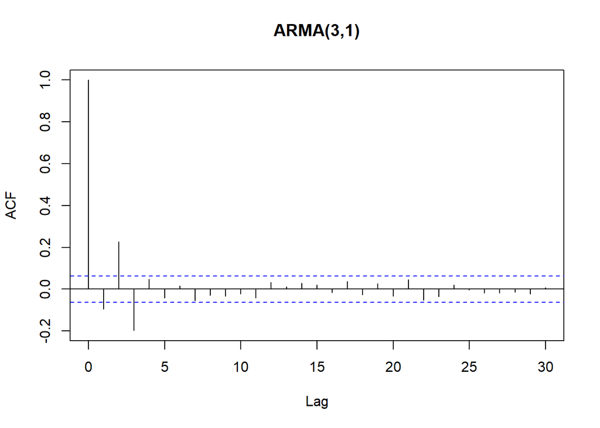

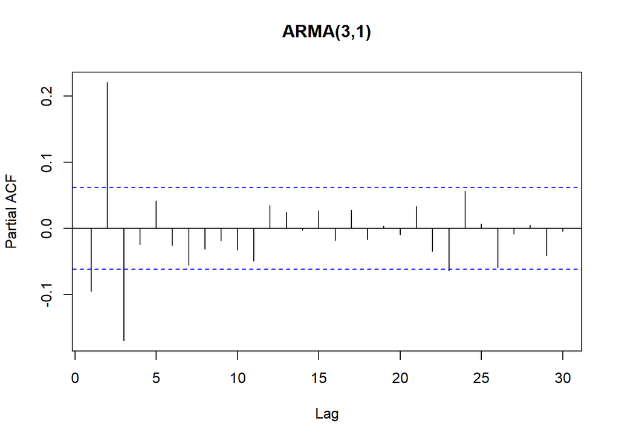

```r
plotcorr(armats1,main="ARMA(3,1)")
```

```r
# Simulate an ARMA(1,3) with certain parameters
ar=c(0.1)
ma=c(0.1,-0.1,-0.1)
order=c(1,0,3)
armats2=arma(ar,ma)
armatsfit2 = armafit(armats2, order)
stargazer(armatsfit2, type="text")
```

```
##
## =============================================
##                       Dependent variable:
##                   ---------------------------
##                             armats
## ---------------------------------------------
## ar1                          0.228
##                             (0.226)
##
## ma1                          0.027
##                             (0.225)
##
## ma2                        -0.184***
##                             (0.059)
##
## ma3                        -0.136***
##                             (0.041)
##
## ---------------------------------------------
## Observations                 1,000
## Log Likelihood            -1,432.671
## sigma2                       1.028
## Akaike Inf. Crit.          2,875.342
## =============================================
## Note:             *p<0.1; **p<0.05; ***p<0.01
```

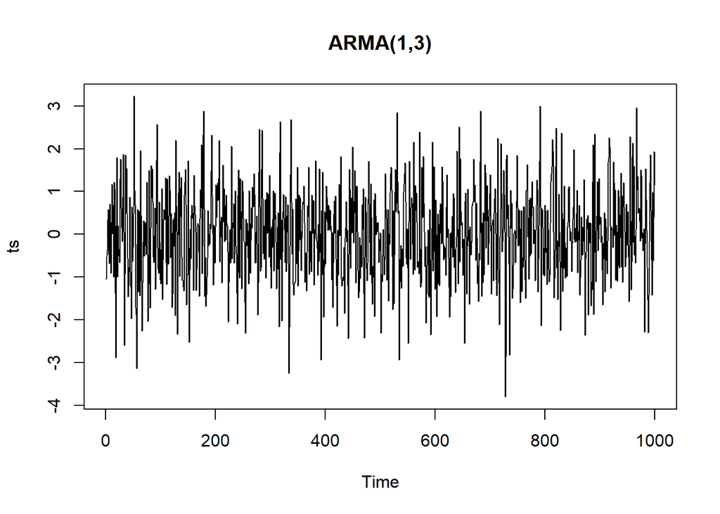

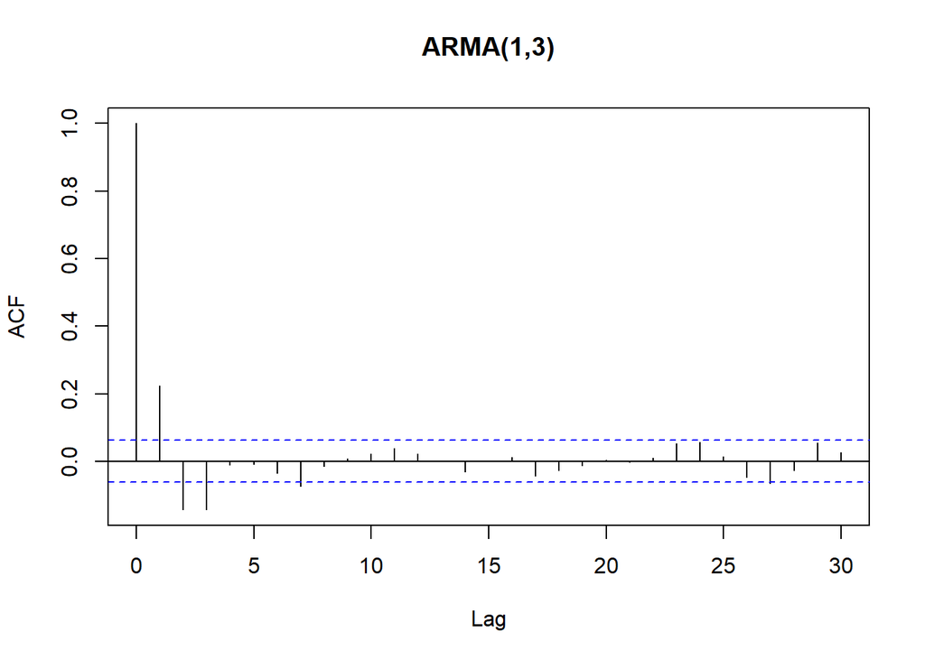

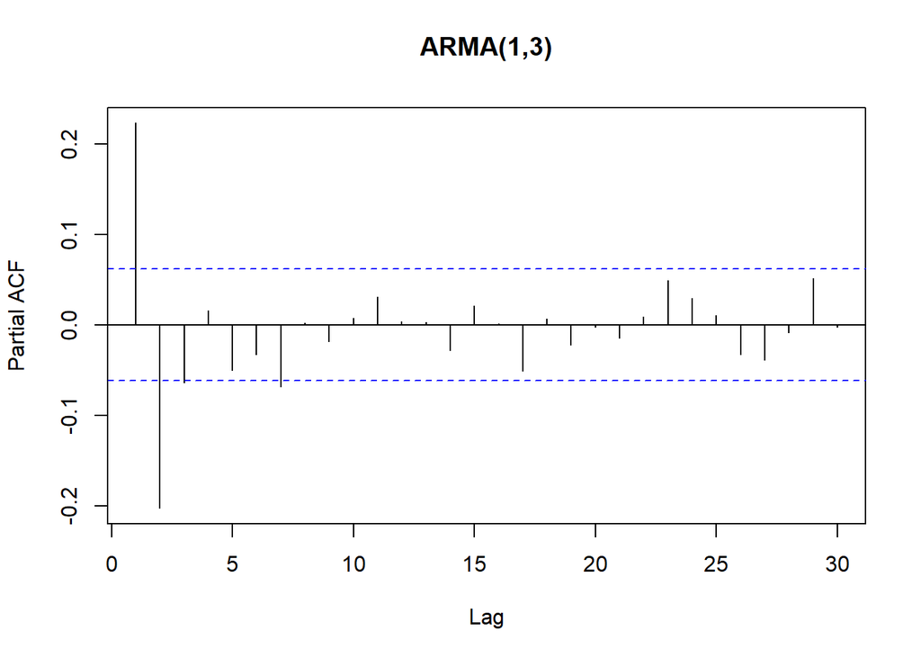

```r
plotcorr(armats2,main="ARMA(1,3)")
```

Also here, coefficients are coherent with what we expected, even if the presence of multiple lags tends to weaken their correspondence with the parameters we set.

## Q2: Forecasting Comparison

We decided to simulate an ARMA(2,1) as a baseline time series

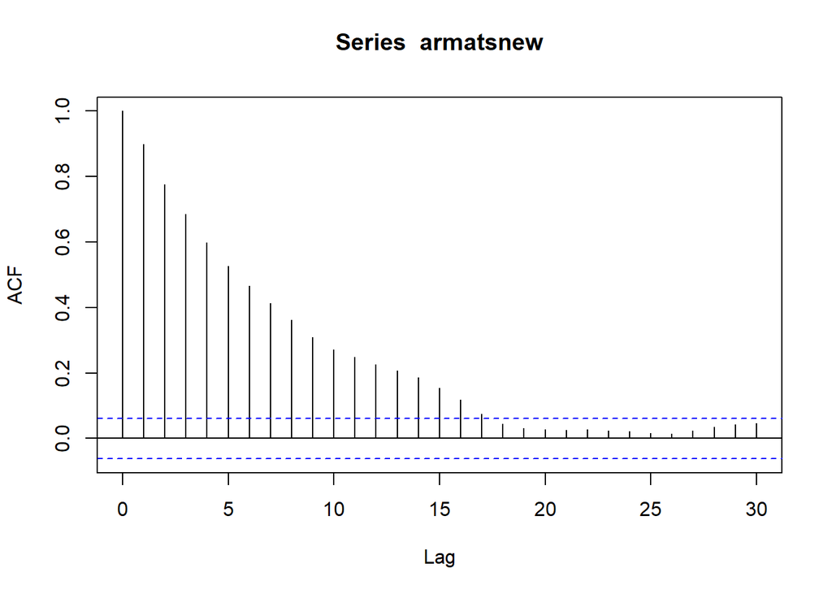

```r
# Simulating an arma(2,1) as a baseline time series
ar=c(0.43,0.37)
ma=c(0.6)
order=c(2,0,1)
armatsnew=arma(ar,ma)
acf(armatsnew)
```

And then we divide our sample time series in two parts: the train set for estimation and the test set to forecast

```r
n=length(armatsnew)/2
armatstrain=armatsnew[1:n]
armatstest=armatsnew[(n+1):length(armatsnew)]
```

After that, we fit AR(1), ARMA(2,1), naive forecast, mean forecast on the train set to obtain parameters to predict future values. Using this prediction, we calculate the errors using MAE and RMSE to compare values.

```r
#Model fitting with an AR(1),
order=c(1,0,0)
arfit=armafit(armatstrain,order)
summary(arfit)
```

```
##
## Call:
## arima(x = armats, order = order, include.mean = FALSE)
##
## Coefficients:
##          ar1
##       0.8919
## s.e.  0.0200
##
## sigma^2 estimated as 1.005:  log likelihood = -711.45,  aic = 1426.89
##
## Training set error measures:
```

```
##               ME RMSE MAE MPE MAPE
## Training set NaN  NaN NaN NaN  NaN
```

```r
arfitpred=predict(arfit,n.ahead=500, interval="confidence")
maear=mae(armatstest,arfitpred$pred)
rmsear=rmse(armatstest,arfitpred$pred)
cbind(maear,rmsear)
```

```
##         maear   rmsear
## [1,] 1.934651 2.312656
```

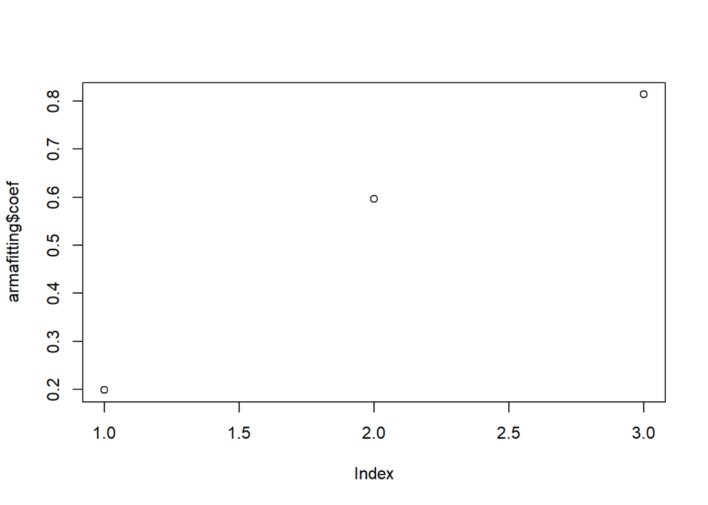

```r
#Model fitting with ARMA(2,1)
order=c(2,0,1)
armafitting=armafit(armatstrain,order)
plot(armafitting$coef)
```

```r
summary(armafitting)
```

```
##
## Call:
## arima(x = armats, order = order, include.mean = FALSE)
##
## Coefficients:
##          ar1     ar2     ma1
##       0.1986  0.5968  0.8140
## s.e.  0.1136  0.1067  0.0916
##
## sigma^2 estimated as 0.9728:  log likelihood = -703.43,  aic = 1414.86
##
## Training set error measures:
```

```
##               ME RMSE MAE MPE MAPE
## Training set NaN  NaN NaN NaN  NaN
```

```r
armafitpred=predict(armafitting,n.ahead=500, interval="confidence")
maearma=mae(armatstest,armafitpred$pred)
rmsearma=rmse(armatstest,armafitpred$pred)
cbind(maearma,rmsearma)
```

```
##       maearma rmsearma
## [1,] 1.932179 2.310731
```

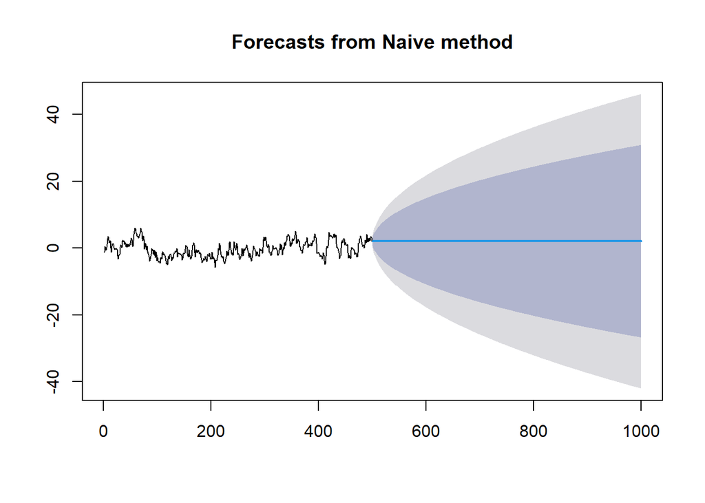

```r
#Model fitting with naive forecast
naivefit=naive(armatstest, h=500)
plot(naivefit)
```

```r
naivefitpred=predict(naivefit,n.ahead=500, interval="confidence")
maenaive=mae(armatstest,naivefitpred$fitted[-c(1)])
rmsenaive=rmse(armatstest,naivefitpred$fitted[-c(1)])
cbind(maenaive,rmsenaive)
```

```
##         maenaive rmsenaive
## [1,] 0.006339533 0.1417563
```

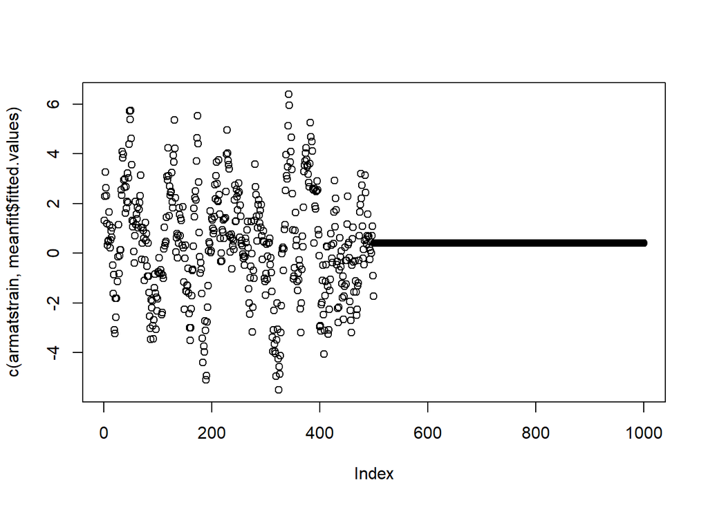

```r
#Model fitting with mean forecast
meanfit=lm(armatstrain ~ 1)
plot(c(armatstrain,meanfit$fitted.values))
```

```r
meanfitpred=predict(meanfit,n.ahead=500, interval="confidence")
maemean=mae(armatstest,meanfit[["coefficients"]])
rmsemean=rmse(armatstest,meanfit[["coefficients"]])
cbind(maemean,rmsemean)
```

```
##       maemean rmsemean
## [1,] 1.992984 2.376005
```

## Q3: Nelson Plosser data

Point 3 is in another R Markdown file named “Point-3.Rmd”

## Q4:Cointegration

First of all we download from FRED the following interest rates: 3 Months Treasury Bill, 2 Years Treasury Bonds and 10 Years Treasury Bonds

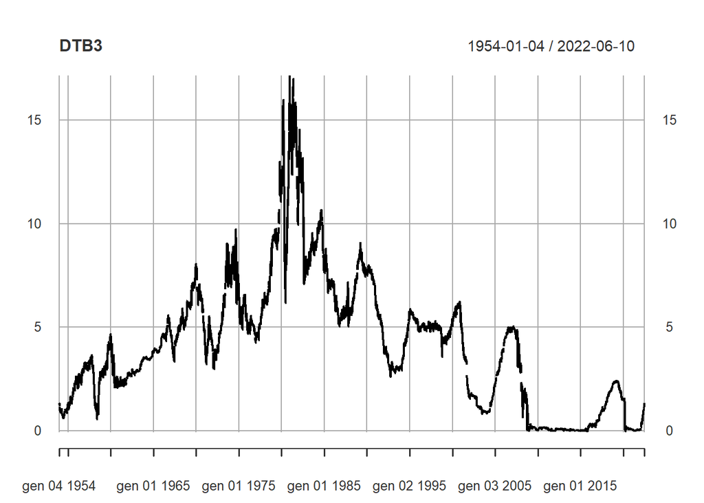

```r
rates <- c("DTB3","DGS2","DGS10")
for (i in 1:length(rates)) {
  getSymbols(rates[i], src = "FRED")
}
plot(DTB3)
```

We decide to clean the time series from days of market closure

```r
nas=c(which(is.na(DTB3)))
for (i in 1:length(nas)){
  DTB3[nas[i]]=DTB3[nas[i]-1]
}

nas2=c(which(is.na(DGS2)))
for (i in 1:length(nas2)){
  DGS2[nas2[i]]=DGS2[nas2[i]-1]
}

nas3=c(which(is.na(DGS10)))
for (i in 1:length(nas3)){
  DGS10[nas3[i]]=DGS10[nas3[i]-1]
}
```

Secondly, we need to construct the term spread, that is = DGS10 - DTB3. It is a proxy of the risk in holding longer maturities with respect to liquid cash or very short term Treasury Bills.

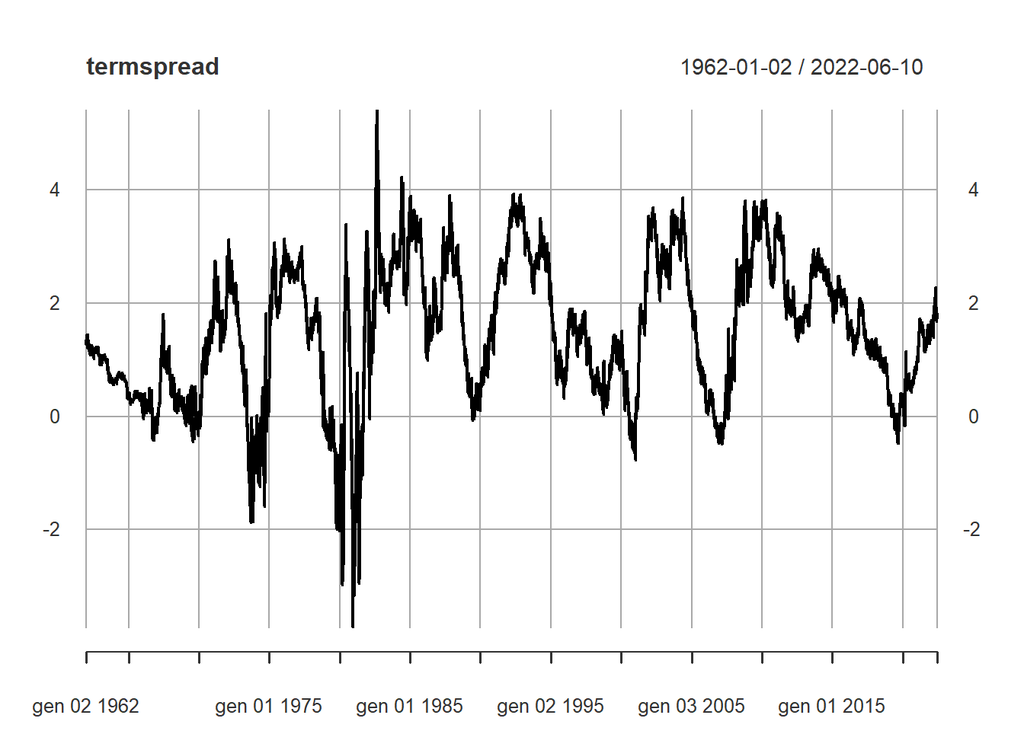

```r
termspread=DGS10-DTB3
plot(termspread)
```

Moreover we construct the indicator for an advent the recession, that is = DGS10 - DGS2, if negative is an indicator of recession

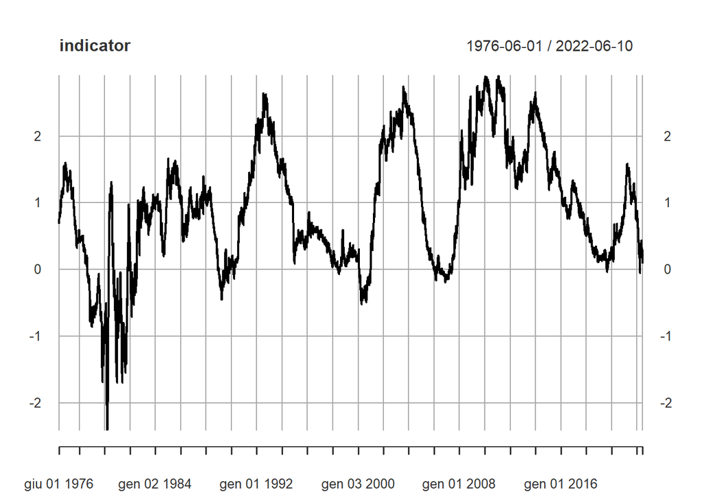

```r
indicator=DGS10-DGS2
plot(indicator)
```

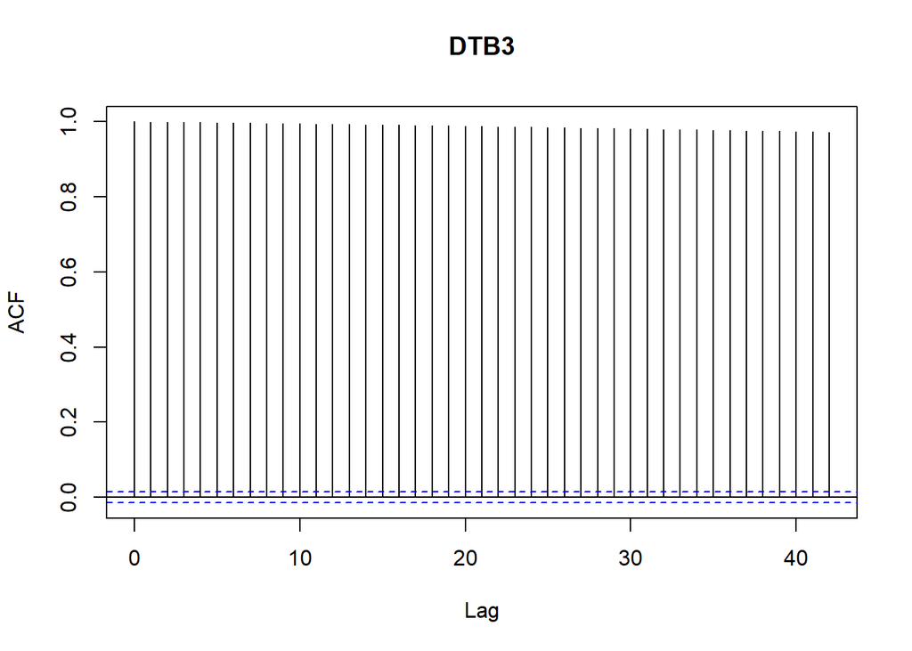

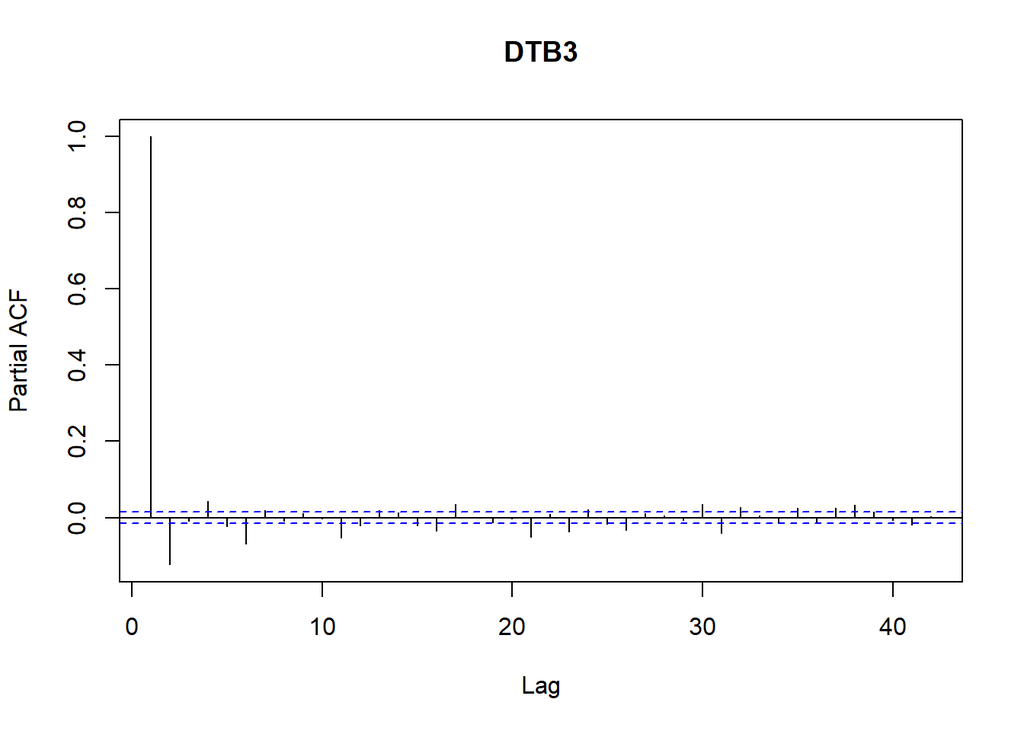

```r
# we plot also the correlation
plotcorr(DTB3, main="DTB3")
```

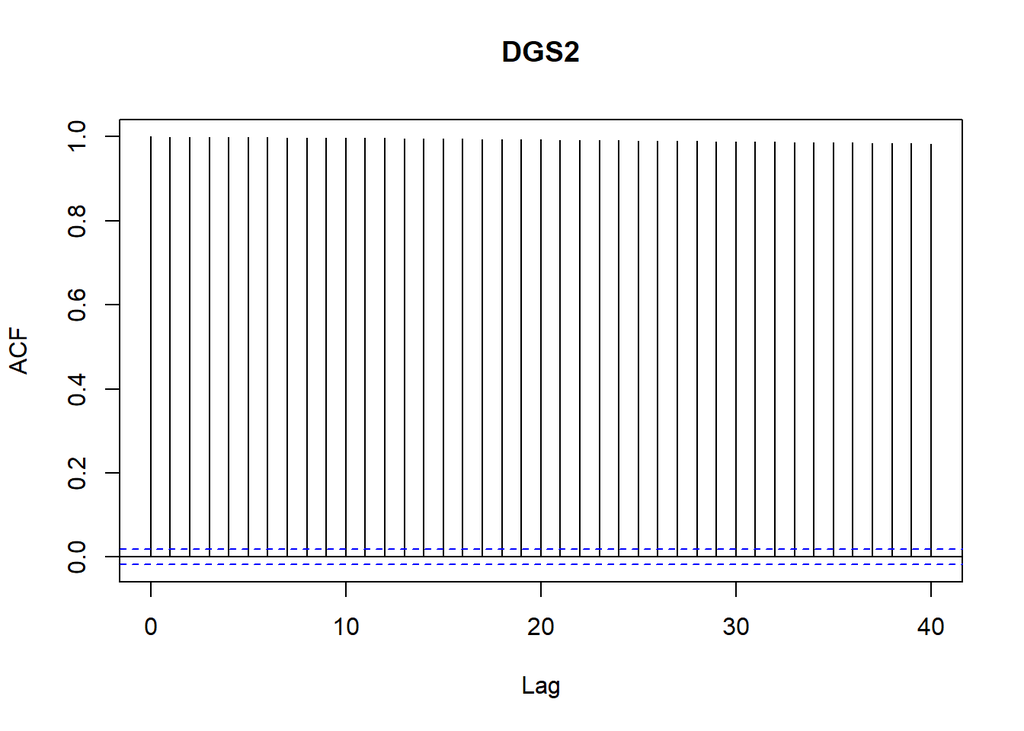

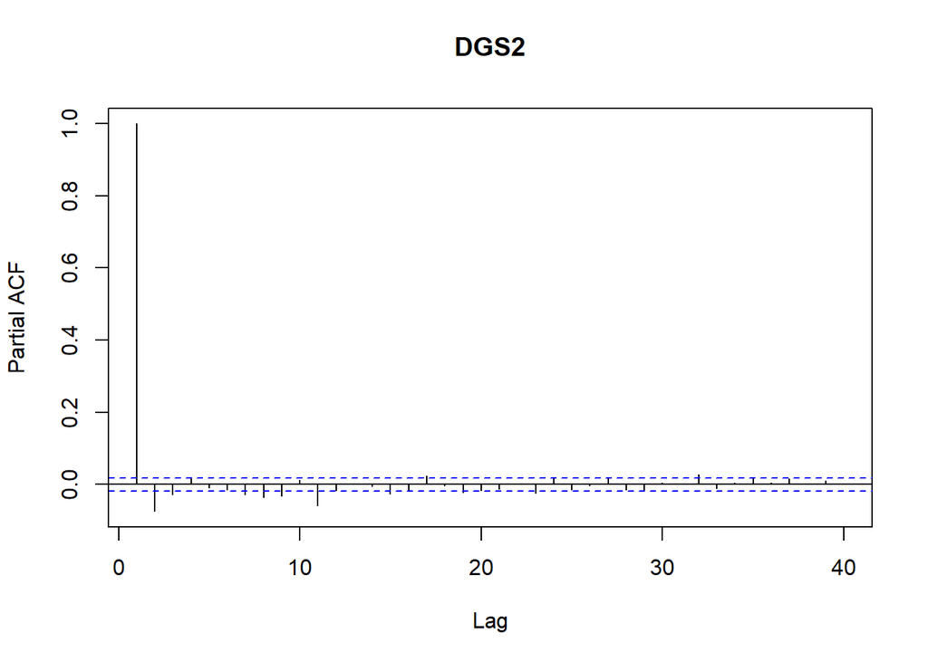

```r
plotcorr(DGS2, main="DGS2")
```

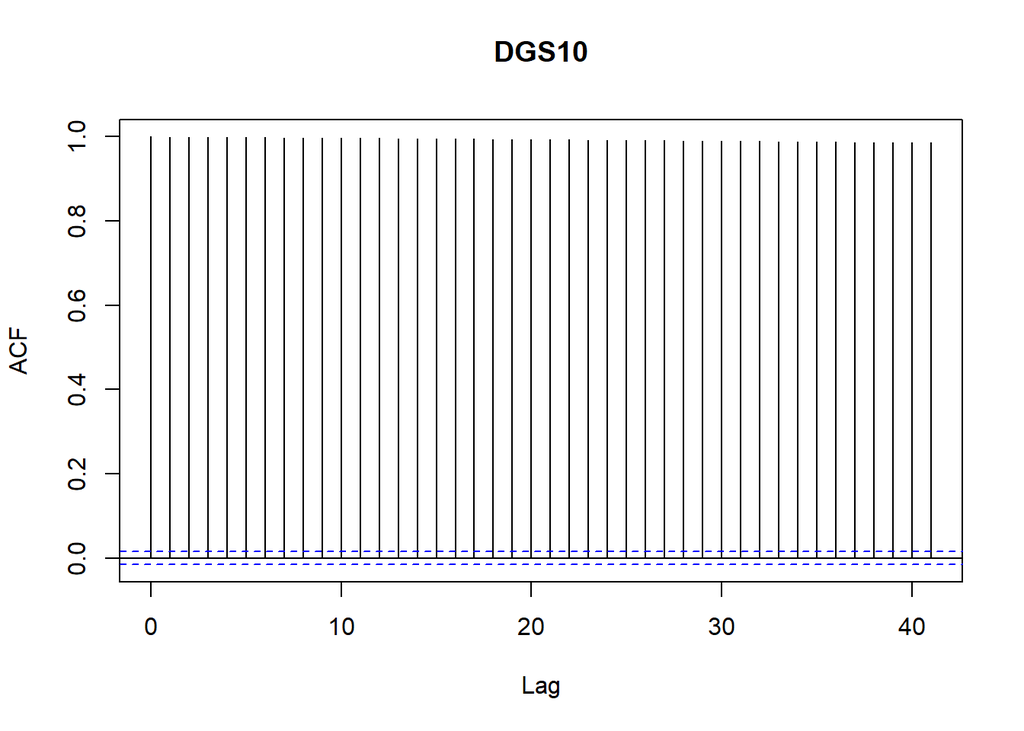

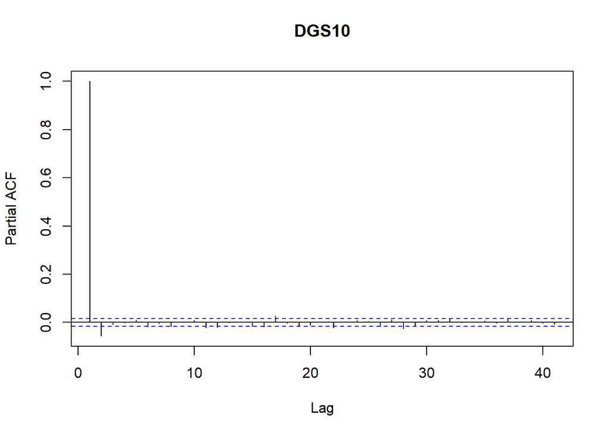

```r
plotcorr(DGS10, main="DGS10")
```

We create a matrix of potential combinations of ARMA orders going from ARMA(1,0,1) all the way to ARMA(3,0,3)

```r
ordercomb=NULL
ordercomb=matrix(NA,nrow=9,ncol=3)
for (z in 1:3){
  for (x in 1:3){
    ordercomb[x+3*(z-1),]=c(x,0,z)
  }
}

ordercomb
```

```
##       [,1] [,2] [,3]
##  [1,]    1    0    1
##  [2,]    2    0    1
##  [3,]    3    0    1
##  [4,]    1    0    2
##  [5,]    2    0    2
##  [6,]    3    0    2
##  [7,]    1    0    3
##  [8,]    2    0    3
##  [9,]    3    0    3
```

And obviously we check which one is the best model specification for DTB3

```r
dtb3train=DTB3[1:(length(DTB3)*0.8)]
dtb3test=DTB3[((length(DTB3)*0.8)+1):length(DTB3)]

order=ordercomb[1,]
fit=armafit(dtb3train,order)
fitpred=predict(fit,n.ahead=length(dtb3test), interval="confidence")
mae=mae(dtb3test,fitpred$pred)
rmse=rmse(dtb3test,fitpred$pred)


maelist=c()
rmselist=c()
aiclist=c()
biclist=c()
for (c in 1:nrow(ordercomb)){
  order=ordercomb[c,]
  fit=armafit(dtb3train,order)
  fitpred=predict(fit,n.ahead=length(dtb3test), interval="confidence")
  maelist[c]=mae(dtb3test,fitpred$pred)
  rmselist[c]=rmse(dtb3test,fitpred$pred)
  aiclist[c]=-1*AIC(fit)
  biclist[c]=-1*BIC(fit)
}

errorlist=cbind(maelist, rmselist, aiclist, biclist)
which.min(errorlist[,1])
```

```
## [1] 3
```

```r
which.min(errorlist[,2])
```

```
## [1] 9
```

```r
which.min(errorlist[,3])
```

```
## [1] 1
```

```r
which.min(errorlist[,4])
```

```
## [1] 1
```

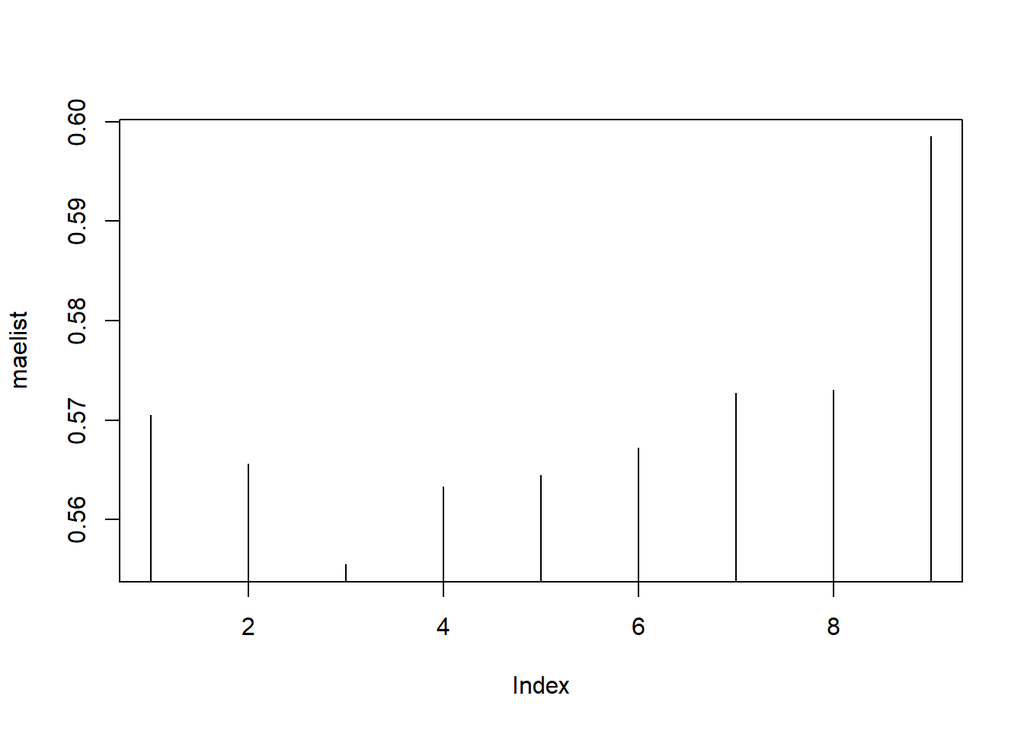

```r
plot(maelist, type= "h")
```